# 2024-08-14_Hypothesis1_MultilevelModel

2024-11-27

**Attentional Biases in OCD**  
**Script Part II / ?**  
**Date: 24.07.2024**  
**Version: Version 2**

# Description

This is the main analysis file of hypothesis 1 of the 044_EYE project on Attentional Biases in OCD. This script includes the multilevel model that aims to test the main hypotheses. Furthermore, this script contains tests of the assumptions of multilevel models as well as descriptive plots.

## Hypotheses

### 1.) Vigilance Bias:

Patients with **OCD** and patients with **spider phobia** attend to **idiosyncratic disorder-relevant material faster** than they do to **neutral** or **negative** material (vigilance bias), as indicated by the entry time to the corresponding region of interest. **Healthy participants** will **not show a bias** towards disorder-relevant stimuli compared to negative or neutral stimuli.

### 2.) Maintenance Bias:

**a.**  
Patients with **OCD** look at **idiosyncratic OCD-relevant material longer** compared to **neutral** or **negative** material (maintenance bias). **b.**  
Patients with **OCD** will show a **more pronounced maintenance bias** compared to **healthy** participants and, with regard to **idiosyncratic disorder-specific material**, compared to patients with **spider phobia**.

### 3.) Attentional Control

#### Subjective Measure

**a.**  
In patients with **OCD** and patients with **spider phobia**, there will be a **positive association** between **vigilance bias** and **attentional control** as measured by the self-report questionnaire (Attentional Control Scale). This means the lower the attentional control, the faster patients with OCD or spider phobia will look at OCD-relevant or spider-relevant material, respectively, compared to negative or neutral material. **b.**  
In patients with **OCD**, there will be a **negative association** between the **maintenance bias** and **attentional control** as measured by the self-report questionnaire (Attentional Control Scale). This means the lower the attentional control, the longer patients will look at idiosyncratic OCD-relevant material compared to negative or neutral material.

####Objective Measure **c.** In patients with **OCD** and patients with **spider phobia**, there will be a positive association between **vigilance bias** and **attentional control** as measured by the objective measure (AX-CPT). **d.** In patients with **OCD**, there will be a **negative association** between the **maintenance bias** and **attentional control** as measured by the objective measure (AX-CPT).

### 4.) Stress

The induction of **stress** significantly increases the **maintenance bias** in patients with **OCD** (state-level). This means that patients with OCD will **look at OCD-relevant material for longer** after the stress induction than before the stress induction.

**Install Packages**

**Load Packages**

**Define the Colour Scheme**

# Install Julia

```r
library(JuliaCall)
options(JULIA_HOME = "/Applications/Julia-1.11.app/Contents/Resources/julia/bin") # need to define the path for my Mac to resolve bug
j = julia_setup(installJulia = TRUE)
```

```
## Julia version 1.11.0 at location /Applications/Julia-1.11.app/Contents/Resources/julia/bin will be used.
```

```
## Loading setup script for JuliaCall...
```

```
## Finish loading setup script for JuliaCall.
```

## Install Julia Packages

```
## "lmerTest::lmer"
```

# Load Data

```r
# data_dwelltime = read.csv("../data/data_dwelltime_OA.csv")
# data_entrytime = read.csv("../data/data_entrytime_OA.csv")
data_dwelltime = read.csv("/Volumes/109-psy-kp-study/044_EYE/05_Analyses/02_Main Project/01_Scripts/00_Github/project-ocd/data/2024-08-13_data_dwelltime_OA.csv")
data_entrytime = read.csv("/Volumes/109-psy-kp-study/044_EYE/05_Analyses/02_Main Project/01_Scripts/00_Github/project-ocd/data/2024-08-13_data_entrytime_OA.csv")

# Ensure participant IDs match between entry-time and dwell-time datasets
data_entrytime$participant = data_dwelltime$participant

# Set reaction time (rt) for the left stimulus using the first entry time to the lower-left position
data_entrytime$rt = data_entrytime$first_entry_time_left

# For trials where the right stimulus was fixated first, update reaction time with the first entry time to the upper-right position
ix_right = is.na(data_entrytime$first_entry_time_left)
data_entrytime$rt[ix_right] = data_entrytime$first_entry_time_right[ix_right]

# Determine which stimulus (lower-left or upper-right) was fixated first and store the corresponding stimulus ID
data_entrytime$response = data_entrytime$first_entry_ID_left
data_entrytime$response[ix_right] = data_entrytime$first_entry_ID_right[ix_right]

# Set contrasts for stimuli attributes based on their positions (lower-left: -1, upper-right: +1)
data_entrytime$ocd_left = data_entrytime$stim_ocd == -1
data_entrytime$ocd_right = data_entrytime$stim_ocd == 1

data_entrytime$pho_left = data_entrytime$stim_pho == -1
data_entrytime$pho_right = data_entrytime$stim_pho == 1

data_entrytime$neg_left = data_entrytime$stim_neg == -1
data_entrytime$neg_right = data_entrytime$stim_neg == 1

# Identify which direction the participant looked first (ir = upper-right, il = lower-left)
data_entrytime$looked_right = is.na(data_entrytime$first_entry_ID_left)
ir = data_entrytime$looked_right
il = !data_entrytime$looked_right

# Initialize columns to store the type of stimulus looked at and not looked at
data_entrytime$looked_at = 'neutral'
data_entrytime$not_looked_at = 'neutral'

# Set 'looked_at' based on whether the first fixation was on the lower-left or upper-right stimulus with specific attributes
ix = (il & data_entrytime$pho_left) | (ir & data_entrytime$pho_right)
data_entrytime$looked_at[ix] = "pho"

ix = (il & data_entrytime$ocd_left) | (ir & data_entrytime$ocd_right)
data_entrytime$looked_at[ix] = "ocd"

ix = (il & data_entrytime$neg_left) | (ir & data_entrytime$neg_right)
data_entrytime$looked_at[ix] = "neg"

# Set 'not_looked_at' based on the attribute of the stimulus that was not fixated on first
ix = (ir & data_entrytime$pho_left) | (il & data_entrytime$pho_right)
data_entrytime$not_looked_at[ix] = "pho"

ix = (ir & data_entrytime$ocd_left) | (il & data_entrytime$ocd_right)
data_entrytime$not_looked_at[ix] = "ocd"

ix = (ir & data_entrytime$neg_left) | (il & data_entrytime$neg_right)
data_entrytime$not_looked_at[ix] = "neg"
```

# Hypothesis 1: Maintenance Bias

**From Complex to Simple Multilevel Models** ## Hypothesis 1: Create Models

```r
#j $assign("form", formula(mlm_dwelltime))
j$assign("jl_data_dwelltime", data_dwelltime)
j$assign("jl_data_entrytime", data_entrytime)
julia_command("jl_data_entrytime.response .= jl_data_entrytime.response .-1")
```

```
## 25608-element Vector{Int64}:
##  1
##  1
##  0
##  1
##  0
##  1
##  0
##  0
##  0
##  1
##  ⋮
##  1
##  1
##  0
##  1
##  1
##  1
##  1
##  1
##  1
```

```r
julia_command("using MixedModels")
```

```r
julia_command("using JellyMe4")
```

```r
# Model 1: Most Complex Model
julia_command("h1_fm_complex = @formula(dwell_diff ~ group + stim_ocd + stim_pho + stim_neg + group&stim_ocd + group&stim_pho + group&stim_neg +
              (1 + stim_ocd + stim_pho + stim_neg | triplet)+
              (1 + stim_ocd + stim_pho + stim_neg | participant) +
              (1 + group | picture_pair_countingindex))")
```

```
## FormulaTerm
## Response:
##   dwell_diff(unknown)
## Predictors:
##   group(unknown)
##   stim_ocd(unknown)
##   stim_pho(unknown)
##   stim_neg(unknown)
##   group(unknown) & stim_ocd(unknown)
##   group(unknown) & stim_pho(unknown)
##   group(unknown) & stim_neg(unknown)
##   (stim_ocd,stim_pho,stim_neg,triplet)->(1 + stim_ocd + stim_pho + stim_neg) | triplet
##   (stim_ocd,stim_pho,stim_neg,participant)->(1 + stim_ocd + stim_pho + stim_neg) | participant
##   (group,picture_pair_countingindex)->(1 + group) | picture_pair_countingindex
```

```r
# Model 2a: Triplet ZeroCorr
julia_command("h1_fm_triplet_zerocorr = @formula(dwell_diff ~ group + stim_ocd + stim_pho + stim_neg + group&stim_ocd + group&stim_pho + group&stim_neg +
              zerocorr(1 + stim_ocd + stim_pho + stim_neg | triplet)+
              (1 + stim_ocd + stim_pho + stim_neg | participant) +
              (1 + group | picture_pair_countingindex))")
```

```
## FormulaTerm
## Response:
##   dwell_diff(unknown)
## Predictors:
##   group(unknown)
##   stim_ocd(unknown)
##   stim_pho(unknown)
##   stim_neg(unknown)
##   group(unknown) & stim_ocd(unknown)
##   group(unknown) & stim_pho(unknown)
##   group(unknown) & stim_neg(unknown)
##   (stim_ocd,stim_pho,stim_neg,triplet)->zerocorr((1 + stim_ocd + stim_pho + stim_neg) | triplet)
##   (stim_ocd,stim_pho,stim_neg,participant)->(1 + stim_ocd + stim_pho + stim_neg) | participant
##   (group,picture_pair_countingindex)->(1 + group) | picture_pair_countingindex
```

```r
# Model 2b: Triplet and Participant ZeroCorr
julia_command("h1_fm_triplet_id_zerocorr = @formula(dwell_diff ~ group + stim_ocd + stim_pho + stim_neg + group&stim_ocd + group&stim_pho + group&stim_neg +
              zerocorr(1 + stim_ocd + stim_pho + stim_neg | triplet)+
              zerocorr(1 + stim_ocd + stim_pho + stim_neg | participant) +
              (1 + group | picture_pair_countingindex))")
```

```
## FormulaTerm
## Response:
##   dwell_diff(unknown)
## Predictors:
##   group(unknown)
##   stim_ocd(unknown)
##   stim_pho(unknown)
##   stim_neg(unknown)
##   group(unknown) & stim_ocd(unknown)
##   group(unknown) & stim_pho(unknown)
##   group(unknown) & stim_neg(unknown)
##   (stim_ocd,stim_pho,stim_neg,triplet)->zerocorr((1 + stim_ocd + stim_pho + stim_neg) | triplet)
##   (stim_ocd,stim_pho,stim_neg,participant)->zerocorr((1 + stim_ocd + stim_pho + stim_neg) | participant)
##   (group,picture_pair_countingindex)->(1 + group) | picture_pair_countingindex
```

```r
# Model 2c: Triplet, Participant and Item Effect ZeroCorr
julia_command("h1_fm_triplet_id_item_zerocorr = @formula(dwell_diff ~ group + stim_ocd + stim_pho + stim_neg + group&stim_ocd + group&stim_pho + group&stim_neg +
              zerocorr(1 + stim_ocd + stim_pho + stim_neg | triplet)+
              zerocorr(1 + stim_ocd + stim_pho + stim_neg | participant) +
              zerocorr(1 + group | picture_pair_countingindex))")
```

```
## FormulaTerm
## Response:
##   dwell_diff(unknown)
## Predictors:
##   group(unknown)
##   stim_ocd(unknown)
##   stim_pho(unknown)
##   stim_neg(unknown)
##   group(unknown) & stim_ocd(unknown)
##   group(unknown) & stim_pho(unknown)
##   group(unknown) & stim_neg(unknown)
##   (stim_ocd,stim_pho,stim_neg,triplet)->zerocorr((1 + stim_ocd + stim_pho + stim_neg) | triplet)
##   (stim_ocd,stim_pho,stim_neg,participant)->zerocorr((1 + stim_ocd + stim_pho + stim_neg) | participant)
##   (group,picture_pair_countingindex)->zerocorr((1 + group) | picture_pair_countingindex)
```

```r
# Model 3a: Exclude Participant
julia_command("h1_fm_excl_id = @formula(dwell_diff ~ group + stim_ocd + stim_pho + stim_neg + group&stim_ocd + group&stim_pho + group&stim_neg +
              (1 + stim_ocd + stim_pho + stim_neg | triplet)+
              (1 + group | picture_pair_countingindex))")
```

```
## FormulaTerm
## Response:
##   dwell_diff(unknown)
## Predictors:
##   group(unknown)
##   stim_ocd(unknown)
##   stim_pho(unknown)
##   stim_neg(unknown)
##   group(unknown) & stim_ocd(unknown)
##   group(unknown) & stim_pho(unknown)
##   group(unknown) & stim_neg(unknown)
##   (stim_ocd,stim_pho,stim_neg,triplet)->(1 + stim_ocd + stim_pho + stim_neg) | triplet
##   (group,picture_pair_countingindex)->(1 + group) | picture_pair_countingindex
```

```r
# Model 3b: Exclude Triplet
julia_command("h1_fm_excl_triplet = @formula(dwell_diff ~ group + stim_ocd + stim_pho + stim_neg + group&stim_ocd + group&stim_pho + group&stim_neg +
              (1 + stim_ocd + stim_pho + stim_neg | participant)+
              (1 + group | picture_pair_countingindex))")
```

```
## FormulaTerm
## Response:
##   dwell_diff(unknown)
## Predictors:
##   group(unknown)
##   stim_ocd(unknown)
##   stim_pho(unknown)
##   stim_neg(unknown)
##   group(unknown) & stim_ocd(unknown)
##   group(unknown) & stim_pho(unknown)
##   group(unknown) & stim_neg(unknown)
##   (stim_ocd,stim_pho,stim_neg,participant)->(1 + stim_ocd + stim_pho + stim_neg) | participant
##   (group,picture_pair_countingindex)->(1 + group) | picture_pair_countingindex
```

```r
# Model 3c: Exclude Item
julia_command("h1_fm_excl_item  = @formula(dwell_diff ~ group + stim_ocd + stim_pho + stim_neg + group&stim_ocd + group&stim_pho + group&stim_neg +
              (1 + stim_ocd + stim_pho + stim_neg | triplet)+
              (1 + stim_ocd + stim_pho + stim_neg | participant))")
```

```
## FormulaTerm
## Response:
##   dwell_diff(unknown)
## Predictors:
##   group(unknown)
##   stim_ocd(unknown)
##   stim_pho(unknown)
##   stim_neg(unknown)
##   group(unknown) & stim_ocd(unknown)
##   group(unknown) & stim_pho(unknown)
##   group(unknown) & stim_neg(unknown)
##   (stim_ocd,stim_pho,stim_neg,triplet)->(1 + stim_ocd + stim_pho + stim_neg) | triplet
##   (stim_ocd,stim_pho,stim_neg,participant)->(1 + stim_ocd + stim_pho + stim_neg) | participant
```

```r
# Model 4a: Exclude Participant and Triplet
julia_command("h1_fm_excl_triplet_id = @formula(dwell_diff ~ group + stim_ocd + stim_pho + stim_neg + group&stim_ocd + group&stim_pho + group&stim_neg +
              (1 + group | picture_pair_countingindex))")
```

```
## FormulaTerm
## Response:
##   dwell_diff(unknown)
## Predictors:
##   group(unknown)
##   stim_ocd(unknown)
##   stim_pho(unknown)
##   stim_neg(unknown)
##   group(unknown) & stim_ocd(unknown)
##   group(unknown) & stim_pho(unknown)
##   group(unknown) & stim_neg(unknown)
##   (group,picture_pair_countingindex)->(1 + group) | picture_pair_countingindex
```

```r
# Model 4b: Exclude Triplet and Item
julia_command("h1_fm_excl_triplet_item = @formula(dwell_diff ~ group + stim_ocd + stim_pho + stim_neg + group&stim_ocd + group&stim_pho + group&stim_neg +
              (1 + stim_ocd + stim_pho + stim_neg | participant))")
```

```
## FormulaTerm
## Response:
##   dwell_diff(unknown)
## Predictors:
##   group(unknown)
##   stim_ocd(unknown)
##   stim_pho(unknown)
##   stim_neg(unknown)
##   group(unknown) & stim_ocd(unknown)
##   group(unknown) & stim_pho(unknown)
##   group(unknown) & stim_neg(unknown)
##   (stim_ocd,stim_pho,stim_neg,participant)->(1 + stim_ocd + stim_pho + stim_neg) | participant
```

```r
# Model 4c: Exclude Participant and Item
julia_command("h1_fm_excl_id_item = @formula(dwell_diff ~ group + stim_ocd + stim_pho + stim_neg + group&stim_ocd + group&stim_pho + group&stim_neg +
              (1 + stim_ocd + stim_pho + stim_neg | triplet))")
```

```
## FormulaTerm
## Response:
##   dwell_diff(unknown)
## Predictors:
##   group(unknown)
##   stim_ocd(unknown)
##   stim_pho(unknown)
##   stim_neg(unknown)
##   group(unknown) & stim_ocd(unknown)
##   group(unknown) & stim_pho(unknown)
##   group(unknown) & stim_neg(unknown)
##   (stim_ocd,stim_pho,stim_neg,triplet)->(1 + stim_ocd + stim_pho + stim_neg) | triplet
```

## Hypothesis 1: Run Models

```r
# # Model 1
# julia_command("h1_fm_complex = fit(LinearMixedModel, h1_fm_complex, jl_data_dwelltime)")
#
# # Models 2: Zero Correlation
# julia_command("h1_fm_trip_zc = fit(LinearMixedModel, h1_fm_triplet_zerocorr, jl_data_dwelltime)")
# julia_command("h1_fm_trip_id_zc = fit(LinearMixedModel, h1_fm_triplet_id_zerocorr, jl_data_dwelltime)")
# julia_command("h1_fm_trip_id_item_zc = fit(LinearMixedModel, h1_fm_triplet_id_item_zerocorr, jl_data_dwelltime)")
#
# # Models 3: Exclude One Random Effect
# julia_command("h1_fm_excl_id = fit(LinearMixedModel, h1_fm_excl_id, jl_data_dwelltime)")
# julia_command("h1_fm_excl_triplet = fit(LinearMixedModel, h1_fm_excl_triplet, jl_data_dwelltime)")
# julia_command("h1_fm_excl_item = fit(LinearMixedModel, h1_fm_excl_item, jl_data_dwelltime)")
#
# # Models 4: Exclude Two Random Effects
# julia_command("h1_fm_excl_triplet_id = fit(LinearMixedModel, h1_fm_excl_triplet_id, jl_data_dwelltime)")
julia_command("h1_fm_excl_triplet_item = fit(LinearMixedModel, h1_fm_excl_triplet_item, jl_data_dwelltime)")
```

```
## Linear mixed model fit by maximum likelihood
##  dwell_diff ~ 1 + group + stim_ocd + stim_pho + stim_neg + group & stim_ocd + group & stim_pho + group & stim_neg + (1 + stim_ocd + stim_pho + stim_neg | participant)
##     logLik     -2 logLik       AIC         AICc          BIC
##  -225587.6214  451175.2429  451221.2429  451221.2860  451408.7080
##
## Variance components:
##                Column     Variance  Std.Dev.   Corr.
## participant (Intercept)    96618.470  310.835
##             stim_ocd      140406.903  374.709 -0.03
##             stim_pho      479287.323  692.306 +0.10 -0.01
##             stim_neg      262875.903  512.714 +0.23 +0.35 +0.11
## Residual                 2493967.136 1579.230
##  Number of obs: 25608; levels of grouping factors: 165
##
##   Fixed-effects parameters:
## ──────────────────────────────────────────────────────────────────
##                                Coef.  Std. Error       z  Pr(>|z|)
## ──────────────────────────────────────────────────────────────────
## (Intercept)                 126.19       42.2847    2.98    0.0028
## group: ocd                 -105.146      63.237    -1.66    0.0964
## group: spider               -64.8894     63.9994   -1.01    0.3106
## stim_ocd                     57.1764     60.9011    0.94    0.3478
## stim_pho                   -223.082      89.4678   -2.49    0.0127
## stim_neg                     56.2529     70.029     0.80    0.4218
## group: ocd & stim_ocd       -91.5383     89.9139   -1.02    0.3086
## group: spider & stim_ocd     14.1765     91.5052    0.15    0.8769
## group: ocd & stim_pho      -366.718     134.117    -2.73    0.0063
## group: spider & stim_pho  -1498.3       136.682   -10.96    <1e-27
## group: ocd & stim_neg      -227.615     102.956    -2.21    0.0271
## group: spider & stim_neg   -289.7       105.104    -2.76    0.0058
## ──────────────────────────────────────────────────────────────────
```

```r
# julia_command("h1_fm_excl_id_item = fit(LinearMixedModel, h1_fm_excl_id_item, jl_data_dwelltime)")
```

## Hypothesis 1: Translate Models to R

```r
# # Model 1: Complex Model
# # h1_fm_complex <- julia_eval("robject(:lmerMod, Tuple([h1_fm_complex,jl_data_dwelltime]));",need_return="R")
#
# # Models 2: Zero Correlation
# h1_fm_trip_zc <- julia_eval("robject(:lmerMod, Tuple([h1_fm_trip_zc,jl_data_dwelltime]));",need_return="R")
# h1_fm_trip_id_zc <- julia_eval("robject(:lmerMod, Tuple([h1_fm_trip_id_zc,jl_data_dwelltime]));",need_return="R")
# # h1_fm_trip_id_item_zc <- julia_eval("robject(:lmerMod, Tuple([h1_fm_trip_id_item_zc,jl_data_dwelltime]));",need_return="R") # error happens in Julia: Error in getStart(start, rho$pp) : incorrect number of theta components (!=15)
#
# # Models 3: Exclude One Random Effect
# h1_fm_excl_id <- julia_eval("robject(:lmerMod, Tuple([h1_fm_excl_id,jl_data_dwelltime]));",need_return="R")
# h1_fm_excl_triplet <- julia_eval("robject(:lmerMod, Tuple([h1_fm_excl_triplet,jl_data_dwelltime]));",need_return="R")
# h1_fm_excl_item <- julia_eval("robject(:lmerMod, Tuple([h1_fm_excl_item,jl_data_dwelltime]));",need_return="R")
#
# # Models 4: Exclude Two Random Effects
# h1_fm_excl_triplet_id <- julia_eval("robject(:lmerMod, Tuple([h1_fm_excl_triplet_id,jl_data_dwelltime]));",need_return="R")
h1_fm_excl_triplet_item <- julia_eval("robject(:lmerMod, Tuple([h1_fm_excl_triplet_item,jl_data_dwelltime]));",need_return="R")
# h1_fm_excl_id_item <- julia_eval("robject(:lmerMod, Tuple([h1_fm_excl_id_item,jl_data_dwelltime]));",need_return="R")
```

### Hypothesis 1: Evaluate Best Fitting Model

```r
# h1_fm_complex, h1_fm_trip_id_item_zc,
# anova(h1_fm_excl_id, h1_fm_trip_zc, h1_fm_trip_id_zc, h1_fm_excl_triplet, h1_fm_excl_item, h1_fm_excl_triplet_id, h1_fm_excl_triplet_item, h1_fm_excl_id_item)

# best: h1_fm_excl_triplet_item

summary(h1_fm_excl_triplet_item)
```

```
## Linear mixed model fit by maximum likelihood . t-tests use Satterthwaite's
##   method [lmerModLmerTest]
## Formula:
## dwell_diff ~ 1 + group + stim_ocd + stim_pho + stim_neg + group:stim_ocd +
##     group:stim_pho + group:stim_neg + (1 + stim_ocd + stim_pho +
##     stim_neg | participant)
##    Data: jellyme4_data
## Control:
## lme4::lmerControl(optCtrl = list(maxeval = 1), optimizer = "nloptwrap",
##     calc.derivs = FALSE, check.nobs.vs.rankZ = "warning", check.nobs.vs.nlev = "warning",
##     check.nlev.gtreq.5 = "ignore", check.nlev.gtr.1 = "warning",
##     check.nobs.vs.nRE = "warning", check.rankX = "message+drop.cols",
##     check.scaleX = "warning", check.formula.LHS = "stop")
##
##       AIC       BIC    logLik  deviance  df.resid
##  451221.2  451408.7 -225587.6  451175.2     25585
##
## Scaled residuals:
##     Min      1Q  Median      3Q     Max
## -4.0275 -0.6389  0.0053  0.6281  4.3313
##
## Random effects:
##  Groups      Name        Variance Std.Dev. Corr
##  participant (Intercept)   96618   310.8
##              stim_ocd     140407   374.7   -0.03
##              stim_pho     479287   692.3    0.10 -0.01
##              stim_neg     262876   512.7    0.23  0.35  0.11
##  Residual                2493967  1579.2
## Number of obs: 25608, groups:  participant, 165
##
## Fixed effects:
##                      Estimate Std. Error       df t value Pr(>|t|)
## (Intercept)            126.19      42.28   162.50   2.984  0.00328 **
## groupocd              -105.15      63.24   159.77  -1.663  0.09833 .
## groupspider            -64.89      64.00   164.05  -1.014  0.31212
## stim_ocd                57.18      60.90   160.72   0.939  0.34922
## stim_pho              -223.08      89.47   157.83  -2.493  0.01368 *
## stim_neg                56.25      70.03   171.56   0.803  0.42292
## groupocd:stim_ocd      -91.54      89.91   156.13  -1.018  0.31022
## groupspider:stim_ocd    14.18      91.51   158.79   0.155  0.87708
```

[output cut: 18 more lines]

```
## grpcd:stm_n   -0.140  0.215  0.092 -0.163 -0.079 -0.680  0.237
## grpspdr:stm_n -0.137  0.092  0.219 -0.160 -0.078 -0.666  0.108
##               grpspdr:stm_c grpcd:stm_p grpspdr:stm_p grpcd:stm_n
## groupocd
## groupspider
## stim_ocd
## stim_pho
## stim_neg
## grpcd:stm_c
## grpspdr:stm_c
## grpcd:stm_p    0.003
## grpspdr:stm_p  0.010         0.437
## grpcd:stm_n    0.109         0.115       0.052
## grpspdr:stm_n  0.243         0.052       0.061         0.453
## optimizer (LN_BOBYQA) convergence code: 5 (fit with MixedModels.jl)
```

```r
tab_model(h1_fm_excl_triplet_item)
```

|  | dwell diff |  |  |
| --- | --- | --- | --- |
| Predictors | Estimates | CI | p |
| (Intercept) | 126.19 | 43.31 – 209.07 | **0.003** |
| group [ocd] | -105.15 | -229.09 – 18.80 | 0.096 |
| group [spider] | -64.89 | -190.33 – 60.55 | 0.311 |
| stim ocd | 57.18 | -62.19 – 176.55 | 0.348 |
| stim pho | -223.08 | -398.44 – -47.72 | **0.013** |
| stim neg | 56.25 | -81.01 – 193.51 | 0.422 |
| group [ocd] × stim ocd | -91.54 | -267.77 – 84.70 | 0.309 |
| group [spider] × stim ocd | 14.18 | -165.18 – 193.53 | 0.877 |
| group [ocd] × stim pho | -366.72 | -629.59 – -103.84 | **0.006** |
| group [spider] × stim pho | -1498.30 | -1766.20 – -1230.40 | **<0.001** |
| group [ocd] × stim neg | -227.62 | -429.42 – -25.82 | **0.027** |
| group [spider] × stim neg | -289.70 | -495.71 – -83.69 | **0.006** |
| Random Effects |  |  |  |
| σ<sup>2</sup> | 2493967.14 |  |  |
| τ<sub>00</sub> <sub>participant</sub> | 96618.47 |  |  |
| τ<sub>11</sub> <sub>participant.stim_ocd</sub> | 140406.90 |  |  |
| τ<sub>11</sub> <sub>participant.stim_pho</sub> | 479287.32 |  |  |
| τ<sub>11</sub> <sub>participant.stim_neg</sub> | 262875.90 |  |  |
| ρ<sub>01</sub> | -0.03 |  |  |
|  | 0.10 |  |  |
|  | 0.23 |  |  |
| ICC | 0.20 |  |  |
| N <sub>participant</sub> | 165 |  |  |
| Observations | 25608 |  |  |
| Marginal R<sup>2</sup> / Conditional R<sup>2</sup> | 0.191 / 0.349 |  |  |

```r
# Export
tab_model(h1_fm_excl_triplet_item, file = "/Volumes/109-psy-kp-study/044_EYE/06_Results/02_Hauptstudie/MaintenanceBias/summary_h1_fm_excl_triplet_item.doc")
```

|  | dwell diff |  |  |
| --- | --- | --- | --- |
| Predictors | Estimates | CI | p |
| (Intercept) | 126.19 | 43.31 – 209.07 | **0.003** |
| group [ocd] | -105.15 | -229.09 – 18.80 | 0.096 |
| group [spider] | -64.89 | -190.33 – 60.55 | 0.311 |
| stim ocd | 57.18 | -62.19 – 176.55 | 0.348 |
| stim pho | -223.08 | -398.44 – -47.72 | **0.013** |
| stim neg | 56.25 | -81.01 – 193.51 | 0.422 |
| group [ocd] × stim ocd | -91.54 | -267.77 – 84.70 | 0.309 |
| group [spider] × stim ocd | 14.18 | -165.18 – 193.53 | 0.877 |
| group [ocd] × stim pho | -366.72 | -629.59 – -103.84 | **0.006** |
| group [spider] × stim pho | -1498.30 | -1766.20 – -1230.40 | **<0.001** |
| group [ocd] × stim neg | -227.62 | -429.42 – -25.82 | **0.027** |
| group [spider] × stim neg | -289.70 | -495.71 – -83.69 | **0.006** |
| Random Effects |  |  |  |
| σ<sup>2</sup> | 2493967.14 |  |  |
| τ<sub>00</sub> <sub>participant</sub> | 96618.47 |  |  |
| τ<sub>11</sub> <sub>participant.stim_ocd</sub> | 140406.90 |  |  |
| τ<sub>11</sub> <sub>participant.stim_pho</sub> | 479287.32 |  |  |
| τ<sub>11</sub> <sub>participant.stim_neg</sub> | 262875.90 |  |  |
| ρ<sub>01</sub> | -0.03 |  |  |
|  | 0.10 |  |  |
|  | 0.23 |  |  |
| ICC | 0.20 |  |  |
| N <sub>participant</sub> | 165 |  |  |
| Observations | 25608 |  |  |
| Marginal R<sup>2</sup> / Conditional R<sup>2</sup> | 0.191 / 0.349 |  |  |

## Hypothesis 1: Test of Hypotheses With Contrasts

To establish contrast codes that directly test the hypotheses, we first code the hypotheses we want to test. Then, we fit the established effects in the contrast() function. This function allows direct inspection of effects. The p-values are estimated by the Satterthwaite method. The p-values are unadjusted.

*Maintenance Bias:* **a.** Patients with *OCD* look at *idiosyncratic OCD-relevant material longer* compared to *neutral* or *negative* material (maintenance bias). **b.** Patients with *OCD* will show a *more pronounced maintenance bias* compared to *healthy* participants and, with regard to *idiosyncratic disorder-specific material*, compared to patients with *spider phobia*.

```r
# Define the model comparisons to test the specific hypothesis of hypothesis 2
g = (glht(h1_fm_excl_triplet_item, (c("stim_ocd + groupocd:stim_ocd >= 0", # Patients with OCD look at idiosyncratic OCD-relevant material longer compared to neutral material (maintenance bias within group)
                            "(stim_ocd + groupocd:stim_ocd) - (stim_neg + groupocd:stim_neg) >= 0", # Patients with OCD look at idiosyncratic OCD-relevant material longer compared to negative material (maintenance bias within group)
                            "groupocd + groupocd:stim_ocd >= 0", # Patients with OCD will show a more pronounced maintenance bias compared to healthy participants (maintenance bias between groups)
                            "(groupocd + stim_ocd + groupocd:stim_ocd) -  (groupspider + stim_pho + groupspider:stim_pho) >= 0" # Patients with OCD will show a more pronounced maintenance to idiosyncratic disorder-specific material compared to patients with spider phobia (maintenance bias between group)
))))

# Satterthwaite is a more conservative method than the likelihood ratio test
# Likelihood ratio tests always compares two models with each other
# this is easy when the contrast is a treatment effect, but more difficult if we have three variables
# Deviation from preregistration - but this option is better, as
# 1. Contrasts are more easily to be implemented with contest(), as we have many different contrasts and three groups that we want to compare within- and between-subjects (LR would only allow two comparisons at a time)
# 2. Satterthwaite is more conservative than Likelihood Ratio Test
contest(h1_fm_excl_triplet_item,g$linfct,joint=FALSE,ddf="Satterthwaite")
```

```
##                                                                                               Estimate
## stim_ocd + groupocd:stim_ocd                                                                 -34.36185
## (stim_ocd + groupocd:stim_ocd) - (stim_neg + groupocd:stim_neg)                              137.00065
## groupocd + groupocd:stim_ocd                                                                -196.68476
## (groupocd + stim_ocd + groupocd:stim_ocd) - (groupspider + stim_pho + groupspider:stim_pho) 1646.76293
##                                                                                             Std. Error
## stim_ocd + groupocd:stim_ocd                                                                  66.14813
## (stim_ocd + groupocd:stim_ocd) - (stim_neg + groupocd:stim_neg)                               87.90045
## groupocd + groupocd:stim_ocd                                                                 108.82150
## (groupocd + stim_ocd + groupocd:stim_ocd) - (groupspider + stim_pho + groupspider:stim_pho)  142.01661
##                                                                                                   df
## stim_ocd + groupocd:stim_ocd                                                                152.3799
## (stim_ocd + groupocd:stim_ocd) - (stim_neg + groupocd:stim_neg)                             154.0911
## groupocd + groupocd:stim_ocd                                                                162.7023
## (groupocd + stim_ocd + groupocd:stim_ocd) - (groupspider + stim_pho + groupspider:stim_pho) 274.5965
##                                                                                                t value
## stim_ocd + groupocd:stim_ocd                                                                -0.5194682
## (stim_ocd + groupocd:stim_ocd) - (stim_neg + groupocd:stim_neg)                              1.5585887
## groupocd + groupocd:stim_ocd                                                                -1.8074071
## (groupocd + stim_ocd + groupocd:stim_ocd) - (groupspider + stim_pho + groupspider:stim_pho) 11.5955658
##                                                                                                  lower
## stim_ocd + groupocd:stim_ocd                                                                -165.04771
## (stim_ocd + groupocd:stim_ocd) - (stim_neg + groupocd:stim_neg)                              -36.64482
## groupocd + groupocd:stim_ocd                                                                -411.56932
## (groupocd + stim_ocd + groupocd:stim_ocd) - (groupspider + stim_pho + groupspider:stim_pho) 1367.18326
##                                                                                                 upper
## stim_ocd + groupocd:stim_ocd                                                                  96.3240
## (stim_ocd + groupocd:stim_ocd) - (stim_neg + groupocd:stim_neg)                              310.6461
## groupocd + groupocd:stim_ocd                                                                  18.1998
## (groupocd + stim_ocd + groupocd:stim_ocd) - (groupspider + stim_pho + groupspider:stim_pho) 1926.3426
##                                                                                                 Pr(>|t|)
## stim_ocd + groupocd:stim_ocd                                                                6.041880e-01
## (stim_ocd + groupocd:stim_ocd) - (stim_neg + groupocd:stim_neg)                             1.211452e-01
## groupocd + groupocd:stim_ocd                                                                7.254613e-02
## (groupocd + stim_ocd + groupocd:stim_ocd) - (groupspider + stim_pho + groupspider:stim_pho) 1.433314e-25
```

```r
rownames_h1_contrast <- c("stim_ocd + groupocd:stim_ocd","(stim_ocd + groupocd:stim_ocd) - (stim_neg + groupocd:stim_neg)", "groupocd + groupocd:stim_ocd", "(groupocd + stim_ocd + groupocd:stim_ocd) - (groupspider + stim_pho + groupspider:stim_pho)")

h1_contrasts <- as.data.table(contest(h1_fm_excl_triplet_item,g$linfct,joint=FALSE,ddf="Satterthwaite"))
h1_contrasts <- h1_contrasts %>%
  dplyr::mutate(contrast = rownames_h1_contrast) %>%
  dplyr::relocate(contrast, .before = Estimate)
datatable(h1_contrasts)
```

|  | contrast | Estimate | Std. Error | df | t value | lower | upper | Pr(>\|t\|) |
| --- | --- | --- | --- | --- | --- | --- | --- | --- |
| 1 | stim_ocd + groupocd:stim_ocd | -34.36185299336193 | 66.14813415021993 | 152.3798627773166 | -0.5194682122904245 | -165.0477057906892 | 96.32399980396528 | 0.6041880028726295 |
| 2 | (stim_ocd + groupocd:stim_ocd) - (stim_neg + groupocd:stim_neg) | 137.0006493544939 | 87.9004483077961 | 154.0911180379281 | 1.558588744334572 | -36.64482342842743 | 310.6461221374152 | 0.1211452291613857 |
| 3 | groupocd + groupocd:stim_ocd | -196.6847590502321 | 108.8215041584814 | 162.7022892066315 | -1.807407098176034 | -411.5693211120205 | 18.19980301155621 | 0.07254613101796835 |
| 4 | (groupocd + stim_ocd + groupocd:stim_ocd) - (groupspider + stim_pho + groupspider:stim_pho) | 1646.762934113423 | 142.0166085887353 | 274.5964548190335 | 11.59556583189696 | 1367.183264258892 | 1926.342603967955 | 1.433313582120465e-25 |

```r
# Export
write_xlsx(h1_contrasts, "/Volumes/109-psy-kp-study/044_EYE/06_Results/02_Hauptstudie/MaintenanceBias/h1_contrasts.xlsx")
```

*Guideline of Interpretation:* **1. Contrast: OCD vs. neutral in OCD group**

A positive value would indicate that OCD-relevant stimuli elicit longer gaze durations than neutral stimuli within the OCD group.

A negative value would indicate that neutral stimuli elicit longer gaze durations than OCD-relevant stimuli within the OCD group.

**2. Contrast**

A positive value would indicate that OCD-relevant stimuli elicit longer gaze durations than negative stimuli within the OCD group.

A negative value would indicate that negative stimuli elicit longer gaze durations than OCD-relevant stimuli within the OCD group.

**3. Contrast: OCD group will show a more pronounced maintenance bias as compared to healthy participants** A positive value would indicate that OCD patients have longer gaze durations on idiosyncratically OCD-relevant material than healthy individuals do on the same type of stimuli.

–> Essentially, this would mean that the maintenance bias effect in OCD patients is more pronounced compared to the healthy group when looking at OCD-relevant stimuli.

A negative value would indicate that OCD patients have shorter gaze durations on idiosyncratically OCD-relevant stimuli compared to the healthy group’s gaze durations on the same type of stimuli.

**4. Contrast: OCD group will show a more pronounced maintenance bias as compared to spider phobia patients**

A positive value would indicate that OCD patients have longer gaze durations on idiosyncratically OCD-relevant material than spider phobia patients do on their idiosyncratically spider-relevant material.

A negative value would indicate that OCD patients have shorter gaze durations on idiosyncratically OCD-relevant stimuli compared to the spider phobia group’s gaze on their idiosyncratically spider-relevant material.

**Interpretation of Results**

OCD patients do not dwell sig. longer at idiosyncratic OCD-relevant material as compared to neutral pictures.

OCD patients do not dwell sig. longer at idiosyncratic OCD-relevant material as compared to negative pictures.

OCD patients do not show a sig. more pronounced maintenance bias on idiosyncratic OCD-relevant material as compared to healthy controls on the same material (rated by matched OCD patient).

OCD patients do show a sig. more pronounced maintenance bias on idiosyncratic OCD-relevant material as compared to spider phobia patients on idiosyncratic spider-phobia material.

# Hypothesis 1 - Sensitivity Analysis: Exclduing 0 Fixations on AOI

```r
data_dwelltime_excl0 <- data_dwelltime %>%
  dplyr::filter(!c(IA_FIXATION_COUNT_left == 0 | IA_FIXATION_COUNT_right == 0))

#j $assign("form", formula(mlm_dwelltime))
j$assign("jl_data_dwelltime_excl0", data_dwelltime_excl0)
julia_command("using MixedModels")
```

```r
julia_command("using JellyMe4")
```

```r
# Model 4b: Exclude Triplet and Item
julia_command("h1_fm_excl_triplet_item_excl0 = @formula(dwell_diff ~ group + stim_ocd + stim_pho + stim_neg + group&stim_ocd + group&stim_pho + group&stim_neg +
              (1 + stim_ocd + stim_pho + stim_neg | participant))")
```

```
## FormulaTerm
## Response:
##   dwell_diff(unknown)
## Predictors:
##   group(unknown)
##   stim_ocd(unknown)
##   stim_pho(unknown)
##   stim_neg(unknown)
##   group(unknown) & stim_ocd(unknown)
##   group(unknown) & stim_pho(unknown)
##   group(unknown) & stim_neg(unknown)
##   (stim_ocd,stim_pho,stim_neg,participant)->(1 + stim_ocd + stim_pho + stim_neg) | participant
```

```r
julia_command("h1_fm_excl_triplet_item_excl0 = fit(LinearMixedModel, h1_fm_excl_triplet_item_excl0, jl_data_dwelltime_excl0)")
```

```
## Linear mixed model fit by maximum likelihood
##  dwell_diff ~ 1 + group + stim_ocd + stim_pho + stim_neg + group & stim_ocd + group & stim_pho + group & stim_neg + (1 + stim_ocd + stim_pho + stim_neg | participant)
##     logLik     -2 logLik       AIC         AICc          BIC
##  -202362.4291  404724.8582  404770.8582  404770.9057  404956.1323
##
## Variance components:
##                Column     Variance  Std.Dev.   Corr.
## participant (Intercept)    78659.366  280.463
##             stim_ocd      137803.425  371.219 -0.05
##             stim_pho      461541.687  679.369 +0.13 +0.00
##             stim_neg      269814.569  519.437 +0.32 +0.35 +0.06
## Residual                 1962166.942 1400.774
##  Number of obs: 23281; levels of grouping factors: 164
##
##   Fixed-effects parameters:
## ───────────────────────────────────────────────────────────────────
##                                 Coef.  Std. Error       z  Pr(>|z|)
## ───────────────────────────────────────────────────────────────────
## (Intercept)                 124.12        39.026     3.18    0.0015
## group: ocd                  -98.3408      57.6528   -1.71    0.0881
## group: spider               -61.7139      59.0727   -1.04    0.2962
## stim_ocd                     59.9285      60.2302    0.99    0.3197
## stim_pho                   -199.68        89.1036   -2.24    0.0250
## stim_neg                      3.02672     71.2426    0.04    0.9661
## group: ocd & stim_ocd       -98.747       87.6772   -1.13    0.2601
## group: spider & stim_ocd      2.03858     90.3565    0.02    0.9820
## group: ocd & stim_pho      -381.896      132.16     -2.89    0.0039
## group: spider & stim_pho  -1413.13       135.495   -10.43    <1e-24
## group: ocd & stim_neg      -198.946      103.972    -1.91    0.0557
## group: spider & stim_neg   -247.623      106.7      -2.32    0.0203
## ───────────────────────────────────────────────────────────────────
```

```r
h1_fm_excl_triplet_item_excl0 <- julia_eval("robject(:lmerMod, Tuple([h1_fm_excl_triplet_item_excl0,jl_data_dwelltime_excl0]));",need_return="R")

summary(h1_fm_excl_triplet_item_excl0)
```

```
## Linear mixed model fit by maximum likelihood . t-tests use Satterthwaite's
##   method [lmerModLmerTest]
## Formula:
## dwell_diff ~ 1 + group + stim_ocd + stim_pho + stim_neg + group:stim_ocd +
##     group:stim_pho + group:stim_neg + (1 + stim_ocd + stim_pho +
##     stim_neg | participant)
##    Data: jellyme4_data
## Control:
## lme4::lmerControl(optCtrl = list(maxeval = 1), optimizer = "nloptwrap",
##     calc.derivs = FALSE, check.nobs.vs.rankZ = "warning", check.nobs.vs.nlev = "warning",
##     check.nlev.gtreq.5 = "ignore", check.nlev.gtr.1 = "warning",
##     check.nobs.vs.nRE = "warning", check.rankX = "message+drop.cols",
##     check.scaleX = "warning", check.formula.LHS = "stop")
##
##       AIC       BIC    logLik  deviance  df.resid
##  404770.9  404956.1 -202362.4  404724.9     23258
##
## Scaled residuals:
##     Min      1Q  Median      3Q     Max
## -3.9838 -0.6798  0.0085  0.6817  4.3717
##
## Random effects:
##  Groups      Name        Variance Std.Dev. Corr
##  participant (Intercept)   78659   280.5
##              stim_ocd     137803   371.2   -0.05
##              stim_pho     461542   679.4    0.13  0.00
##              stim_neg     269815   519.4    0.32  0.35  0.06
##  Residual                1962167  1400.8
## Number of obs: 23281, groups:  participant, 164
##
## Fixed effects:
##                       Estimate Std. Error        df t value Pr(>|t|)
## (Intercept)            124.120     39.026   154.636   3.180  0.00178 **
## groupocd               -98.341     57.653   150.608  -1.706  0.09012 .
## groupspider            -61.714     59.073   160.444  -1.045  0.29773
## stim_ocd                59.929     60.230   153.283   0.995  0.32131
## stim_pho              -199.680     89.104   156.122  -2.241  0.02644 *
## stim_neg                 3.027     71.243   166.137   0.042  0.96616
## groupocd:stim_ocd      -98.747     87.677   148.165  -1.126  0.26188
## groupspider:stim_ocd     2.039     90.356   154.713   0.023  0.98203
```

[output cut: 18 more lines]

```
## grpcd:stm_n   -0.194  0.294  0.128 -0.168 -0.046 -0.685  0.247
## grpspdr:stm_n -0.189  0.128  0.295 -0.164 -0.045 -0.668  0.113
##               grpspdr:stm_c grpcd:stm_p grpspdr:stm_p grpcd:stm_n
## groupocd
## groupspider
## stim_ocd
## stim_pho
## stim_neg
## grpcd:stm_c
## grpspdr:stm_c
## grpcd:stm_p    0.006
## grpspdr:stm_p  0.016         0.443
## grpcd:stm_n    0.112         0.067       0.030
## grpspdr:stm_n  0.246         0.030       0.014         0.458
## optimizer (LN_BOBYQA) convergence code: 5 (fit with MixedModels.jl)
```

```r
tab_model(h1_fm_excl_triplet_item_excl0)
```

|  | dwell diff |  |  |
| --- | --- | --- | --- |
| Predictors | Estimates | CI | p |
| (Intercept) | 124.12 | 47.63 – 200.61 | **0.001** |
| group [ocd] | -98.34 | -211.34 – 14.66 | 0.088 |
| group [spider] | -61.71 | -177.50 – 54.07 | 0.296 |
| stim ocd | 59.93 | -58.13 – 177.98 | 0.320 |
| stim pho | -199.68 | -374.33 – -25.03 | **0.025** |
| stim neg | 3.03 | -136.61 – 142.67 | 0.966 |
| group [ocd] × stim ocd | -98.75 | -270.60 – 73.11 | 0.260 |
| group [spider] × stim ocd | 2.04 | -175.07 – 179.14 | 0.982 |
| group [ocd] × stim pho | -381.90 | -640.94 – -122.85 | **0.004** |
| group [spider] × stim pho | -1413.13 | -1678.71 – -1147.55 | **<0.001** |
| group [ocd] × stim neg | -198.95 | -402.74 – 4.85 | 0.056 |
| group [spider] × stim neg | -247.62 | -456.76 – -38.48 | **0.020** |
| Random Effects |  |  |  |
| σ<sup>2</sup> | 1962166.94 |  |  |
| τ<sub>00</sub> <sub>participant</sub> | 78659.37 |  |  |
| τ<sub>11</sub> <sub>participant.stim_ocd</sub> | 137803.42 |  |  |
| τ<sub>11</sub> <sub>participant.stim_pho</sub> | 461541.69 |  |  |
| τ<sub>11</sub> <sub>participant.stim_neg</sub> | 269814.57 |  |  |
| ρ<sub>01</sub> | -0.05 |  |  |
|  | 0.13 |  |  |
|  | 0.32 |  |  |
| ICC | 0.22 |  |  |
| N <sub>participant</sub> | 164 |  |  |
| Observations | 23281 |  |  |
| Marginal R<sup>2</sup> / Conditional R<sup>2</sup> | 0.188 / 0.371 |  |  |

```r
# Export
tab_model(h1_fm_excl_triplet_item_excl0, file = "/Volumes/109-psy-kp-study/044_EYE/06_Results/02_Hauptstudie/MaintenanceBias/summary_h1_fm_excl_triplet_item_excl0.doc")
```

|  | dwell diff |  |  |
| --- | --- | --- | --- |
| Predictors | Estimates | CI | p |
| (Intercept) | 124.12 | 47.63 – 200.61 | **0.001** |
| group [ocd] | -98.34 | -211.34 – 14.66 | 0.088 |
| group [spider] | -61.71 | -177.50 – 54.07 | 0.296 |
| stim ocd | 59.93 | -58.13 – 177.98 | 0.320 |
| stim pho | -199.68 | -374.33 – -25.03 | **0.025** |
| stim neg | 3.03 | -136.61 – 142.67 | 0.966 |
| group [ocd] × stim ocd | -98.75 | -270.60 – 73.11 | 0.260 |
| group [spider] × stim ocd | 2.04 | -175.07 – 179.14 | 0.982 |
| group [ocd] × stim pho | -381.90 | -640.94 – -122.85 | **0.004** |
| group [spider] × stim pho | -1413.13 | -1678.71 – -1147.55 | **<0.001** |
| group [ocd] × stim neg | -198.95 | -402.74 – 4.85 | 0.056 |
| group [spider] × stim neg | -247.62 | -456.76 – -38.48 | **0.020** |
| Random Effects |  |  |  |
| σ<sup>2</sup> | 1962166.94 |  |  |
| τ<sub>00</sub> <sub>participant</sub> | 78659.37 |  |  |
| τ<sub>11</sub> <sub>participant.stim_ocd</sub> | 137803.42 |  |  |
| τ<sub>11</sub> <sub>participant.stim_pho</sub> | 461541.69 |  |  |
| τ<sub>11</sub> <sub>participant.stim_neg</sub> | 269814.57 |  |  |
| ρ<sub>01</sub> | -0.05 |  |  |
|  | 0.13 |  |  |
|  | 0.32 |  |  |
| ICC | 0.22 |  |  |
| N <sub>participant</sub> | 164 |  |  |
| Observations | 23281 |  |  |
| Marginal R<sup>2</sup> / Conditional R<sup>2</sup> | 0.188 / 0.371 |  |  |

```r
# Define the model comparisons to test the specific hypothesis of hypothesis 2
g = (glht(h1_fm_excl_triplet_item_excl0, (c("stim_ocd + groupocd:stim_ocd >= 0", # Patients with OCD look at idiosyncratic OCD-relevant material longer compared to neutral material (maintenance bias within group)
                            "(stim_ocd + groupocd:stim_ocd) - (stim_neg + groupocd:stim_neg) >= 0", # Patients with OCD look at idiosyncratic OCD-relevant material longer compared to negative material (maintenance bias within group)
                            "groupocd + groupocd:stim_ocd >= 0", # Patients with OCD will show a more pronounced maintenance bias compared to healthy participants (maintenance bias between groups)
                            "(groupocd + stim_ocd + groupocd:stim_ocd) -  (groupspider + stim_pho + groupspider:stim_pho) >= 0" # Patients with OCD will show a more pronounced maintenance to idiosyncratic disorder-specific material compared to patients with spider phobia (maintenance bias between group)
))))

# Satterthwaite is a more conservative method than the likelihood ratio test
# Likelihood ratio tests always compares two models with each other
# this is easy when the contrast is a treatment effect, but more difficult if we have three variables
# Deviation from preregistration - but this option is better, as
# 1. Contrasts are more easily to be implemented with contest(), as we have many different contrasts and three groups that we want to compare within- and between-subjects (LR would only allow two comparisons at a time)
# 2. Satterthwaite is more conservative than Likelihood Ratio Test
contest(h1_fm_excl_triplet_item_excl0,g$linfct,joint=FALSE,ddf="Satterthwaite")
```

```
##                                                                                               Estimate
## stim_ocd + groupocd:stim_ocd                                                                 -38.81843
## (stim_ocd + groupocd:stim_ocd) - (stim_neg + groupocd:stim_neg)                              157.10042
## groupocd + groupocd:stim_ocd                                                                -197.08777
## (groupocd + stim_ocd + groupocd:stim_ocd) - (groupspider + stim_pho + groupspider:stim_pho) 1537.36887
##                                                                                             Std. Error
## stim_ocd + groupocd:stim_ocd                                                                  63.71513
## (stim_ocd + groupocd:stim_ocd) - (stim_neg + groupocd:stim_neg)                               85.99799
## groupocd + groupocd:stim_ocd                                                                 102.89709
## (groupocd + stim_ocd + groupocd:stim_ocd) - (groupspider + stim_pho + groupspider:stim_pho)  137.30098
##                                                                                                   df
## stim_ocd + groupocd:stim_ocd                                                                143.7842
## (stim_ocd + groupocd:stim_ocd) - (stim_neg + groupocd:stim_neg)                             141.5590
## groupocd + groupocd:stim_ocd                                                                155.0582
## (groupocd + stim_ocd + groupocd:stim_ocd) - (groupspider + stim_pho + groupspider:stim_pho) 271.8465
##                                                                                                t value
## stim_ocd + groupocd:stim_ocd                                                                -0.6092498
## (stim_ocd + groupocd:stim_ocd) - (stim_neg + groupocd:stim_neg)                              1.8267918
## groupocd + groupocd:stim_ocd                                                                -1.9153873
## (groupocd + stim_ocd + groupocd:stim_ocd) - (groupspider + stim_pho + groupspider:stim_pho) 11.1970717
##                                                                                                 lower
## stim_ocd + groupocd:stim_ocd                                                                -164.7578
## (stim_ocd + groupocd:stim_ocd) - (stim_neg + groupocd:stim_neg)                              -12.9059
## groupocd + groupocd:stim_ocd                                                                -400.3488
## (groupocd + stim_ocd + groupocd:stim_ocd) - (groupspider + stim_pho + groupspider:stim_pho) 1267.0605
##                                                                                                   upper
## stim_ocd + groupocd:stim_ocd                                                                  87.120918
## (stim_ocd + groupocd:stim_ocd) - (stim_neg + groupocd:stim_neg)                              327.106733
## groupocd + groupocd:stim_ocd                                                                   6.173209
## (groupocd + stim_ocd + groupocd:stim_ocd) - (groupspider + stim_pho + groupspider:stim_pho) 1807.677262
##                                                                                                 Pr(>|t|)
## stim_ocd + groupocd:stim_ocd                                                                5.433204e-01
## (stim_ocd + groupocd:stim_ocd) - (stim_neg + groupocd:stim_neg)                             6.983761e-02
## groupocd + groupocd:stim_ocd                                                                5.728382e-02
## (groupocd + stim_ocd + groupocd:stim_ocd) - (groupspider + stim_pho + groupspider:stim_pho) 3.497206e-24
```

```r
rownames_h1_contrast_excl0 <- c("stim_ocd + groupocd:stim_ocd","(stim_ocd + groupocd:stim_ocd) - (stim_neg + groupocd:stim_neg)", "groupocd + groupocd:stim_ocd", "(groupocd + stim_ocd + groupocd:stim_ocd) - (groupspider + stim_pho + groupspider:stim_pho)")

h1_contrasts_excl0 <- as.data.table(contest(h1_fm_excl_triplet_item_excl0,g$linfct,joint=FALSE,ddf="Satterthwaite"))
h1_contrasts_excl0 <- h1_contrasts_excl0 %>%
  dplyr::mutate(contrast = rownames_h1_contrast_excl0) %>%
  dplyr::relocate(contrast, .before = Estimate)
datatable(h1_contrasts_excl0)
```

|  | contrast | Estimate | Std. Error | df | t value | lower | upper | Pr(>\|t\|) |
| --- | --- | --- | --- | --- | --- | --- | --- | --- |
| 1 | stim_ocd + groupocd:stim_ocd | -38.81843109540547 | 63.71513489500288 | 143.7841904782206 | -0.6092497670981146 | -164.7577797932366 | 87.12091760242566 | 0.543320367666922 |
| 2 | (stim_ocd + groupocd:stim_ocd) - (stim_neg + groupocd:stim_neg) | 157.1004169990624 | 85.99798614360631 | 141.5590342571654 | 1.826791812737609 | -12.90589867405225 | 327.106732672177 | 0.06983761425803153 |
| 3 | groupocd + groupocd:stim_ocd | -197.0877713626109 | 102.8970865205127 | 155.0582000892791 | -1.915387286726734 | -400.348751640376 | 6.173208915154191 | 0.05728381501121415 |
| 4 | (groupocd + stim_ocd + groupocd:stim_ocd) - (groupspider + stim_pho + groupspider:stim_pho) | 1537.368874898844 | 137.3009757810363 | 271.8464777661576 | 11.19707173349297 | 1267.060487400007 | 1807.677262397681 | 3.497205602970936e-24 |

```r
# Export
write_xlsx(h1_contrasts_excl0, "/Volumes/109-psy-kp-study/044_EYE/06_Results/02_Hauptstudie/MaintenanceBias/h1_contrasts_excl0.xlsx")
```

Replicates results shown with total dataset.

# Hypothesis 2: Vigilance Bias

**From Complex to Simple Multilevel Models** ## Hypothesis 2a: Choice (wo Entry Time)

```r
# Model 1: Most Complex Model
julia_command("h2a_glm_fm_complex = @formula(response ~ group + stim_ocd + stim_pho + stim_neg + group&stim_ocd + group&stim_pho + group&stim_neg +
              (1 + stim_ocd + stim_pho + stim_neg | triplet)+
              (1 + stim_ocd + stim_pho + stim_neg | participant) +
              (1 + group | picture_pair_countingindex))")
```

```
## FormulaTerm
## Response:
##   response(unknown)
## Predictors:
##   group(unknown)
##   stim_ocd(unknown)
##   stim_pho(unknown)
##   stim_neg(unknown)
##   group(unknown) & stim_ocd(unknown)
##   group(unknown) & stim_pho(unknown)
##   group(unknown) & stim_neg(unknown)
##   (stim_ocd,stim_pho,stim_neg,triplet)->(1 + stim_ocd + stim_pho + stim_neg) | triplet
##   (stim_ocd,stim_pho,stim_neg,participant)->(1 + stim_ocd + stim_pho + stim_neg) | participant
##   (group,picture_pair_countingindex)->(1 + group) | picture_pair_countingindex
```

```r
# Model 2a: Triplet ZeroCorr
julia_command("h2a_glm_fm_triplet_zerocorr = @formula(response ~ group + stim_ocd + stim_pho + stim_neg + group&stim_ocd + group&stim_pho + group&stim_neg +
              zerocorr(1 + stim_ocd + stim_pho + stim_neg | triplet)+
              (1 + stim_ocd + stim_pho + stim_neg | participant) +
              (1 + group | picture_pair_countingindex))")
```

```
## FormulaTerm
## Response:
##   response(unknown)
## Predictors:
##   group(unknown)
##   stim_ocd(unknown)
##   stim_pho(unknown)
##   stim_neg(unknown)
##   group(unknown) & stim_ocd(unknown)
##   group(unknown) & stim_pho(unknown)
##   group(unknown) & stim_neg(unknown)
##   (stim_ocd,stim_pho,stim_neg,triplet)->zerocorr((1 + stim_ocd + stim_pho + stim_neg) | triplet)
##   (stim_ocd,stim_pho,stim_neg,participant)->(1 + stim_ocd + stim_pho + stim_neg) | participant
##   (group,picture_pair_countingindex)->(1 + group) | picture_pair_countingindex
```

```r
# Model 2b: Triplet and Participant ZeroCorr
julia_command("h2a_glm_fm_triplet_id_zerocorr = @formula(response ~ group + stim_ocd + stim_pho + stim_neg + group&stim_ocd + group&stim_pho + group&stim_neg +
              zerocorr(1 + stim_ocd + stim_pho + stim_neg | triplet)+
              zerocorr(1 + stim_ocd + stim_pho + stim_neg | participant) +
              (1 + group | picture_pair_countingindex))")
```

```
## FormulaTerm
## Response:
##   response(unknown)
## Predictors:
##   group(unknown)
##   stim_ocd(unknown)
##   stim_pho(unknown)
##   stim_neg(unknown)
##   group(unknown) & stim_ocd(unknown)
##   group(unknown) & stim_pho(unknown)
##   group(unknown) & stim_neg(unknown)
##   (stim_ocd,stim_pho,stim_neg,triplet)->zerocorr((1 + stim_ocd + stim_pho + stim_neg) | triplet)
##   (stim_ocd,stim_pho,stim_neg,participant)->zerocorr((1 + stim_ocd + stim_pho + stim_neg) | participant)
##   (group,picture_pair_countingindex)->(1 + group) | picture_pair_countingindex
```

```r
# Model 2c: Triplet, Participant and Item Effect ZeroCorr
julia_command("h2a_glm_fm_triplet_id_item_zerocorr = @formula(response ~ group + stim_ocd + stim_pho + stim_neg + group&stim_ocd + group&stim_pho + group&stim_neg +
              zerocorr(1 + stim_ocd + stim_pho + stim_neg | triplet)+
              zerocorr(1 + stim_ocd + stim_pho + stim_neg | participant) +
              zerocorr(1 + group | picture_pair_countingindex))")
```

```
## FormulaTerm
## Response:
##   response(unknown)
## Predictors:
##   group(unknown)
##   stim_ocd(unknown)
##   stim_pho(unknown)
##   stim_neg(unknown)
##   group(unknown) & stim_ocd(unknown)
##   group(unknown) & stim_pho(unknown)
##   group(unknown) & stim_neg(unknown)
##   (stim_ocd,stim_pho,stim_neg,triplet)->zerocorr((1 + stim_ocd + stim_pho + stim_neg) | triplet)
##   (stim_ocd,stim_pho,stim_neg,participant)->zerocorr((1 + stim_ocd + stim_pho + stim_neg) | participant)
##   (group,picture_pair_countingindex)->zerocorr((1 + group) | picture_pair_countingindex)
```

```r
# Model 3a: Exclude Participant
julia_command("h2a_glm_fm_excl_id = @formula(response ~ group + stim_ocd + stim_pho + stim_neg + group&stim_ocd + group&stim_pho + group&stim_neg +
              (1 + stim_ocd + stim_pho + stim_neg | triplet)+
              (1 + group | picture_pair_countingindex))")
```

```
## FormulaTerm
## Response:
##   response(unknown)
## Predictors:
##   group(unknown)
##   stim_ocd(unknown)
##   stim_pho(unknown)
##   stim_neg(unknown)
##   group(unknown) & stim_ocd(unknown)
##   group(unknown) & stim_pho(unknown)
##   group(unknown) & stim_neg(unknown)
##   (stim_ocd,stim_pho,stim_neg,triplet)->(1 + stim_ocd + stim_pho + stim_neg) | triplet
##   (group,picture_pair_countingindex)->(1 + group) | picture_pair_countingindex
```

```r
# Model 3b: Exclude Triplet
julia_command("h2a_glm_fm_excl_triplet = @formula(response ~ group + stim_ocd + stim_pho + stim_neg + group&stim_ocd + group&stim_pho + group&stim_neg +
              (1 + stim_ocd + stim_pho + stim_neg | participant)+
              (1 + group | picture_pair_countingindex))")
```

```
## FormulaTerm
## Response:
##   response(unknown)
## Predictors:
##   group(unknown)
##   stim_ocd(unknown)
##   stim_pho(unknown)
##   stim_neg(unknown)
##   group(unknown) & stim_ocd(unknown)
##   group(unknown) & stim_pho(unknown)
##   group(unknown) & stim_neg(unknown)
##   (stim_ocd,stim_pho,stim_neg,participant)->(1 + stim_ocd + stim_pho + stim_neg) | participant
##   (group,picture_pair_countingindex)->(1 + group) | picture_pair_countingindex
```

```r
# Model 3c: Exclude Item
julia_command("h2a_glm_fm_excl_item  = @formula(response ~ group + stim_ocd + stim_pho + stim_neg + group&stim_ocd + group&stim_pho + group&stim_neg +
              (1 + stim_ocd + stim_pho + stim_neg | triplet)+
              (1 + stim_ocd + stim_pho + stim_neg | participant))")
```

```
## FormulaTerm
## Response:
##   response(unknown)
## Predictors:
##   group(unknown)
##   stim_ocd(unknown)
##   stim_pho(unknown)
##   stim_neg(unknown)
##   group(unknown) & stim_ocd(unknown)
##   group(unknown) & stim_pho(unknown)
##   group(unknown) & stim_neg(unknown)
##   (stim_ocd,stim_pho,stim_neg,triplet)->(1 + stim_ocd + stim_pho + stim_neg) | triplet
##   (stim_ocd,stim_pho,stim_neg,participant)->(1 + stim_ocd + stim_pho + stim_neg) | participant
```

```r
# Model 4a: Exclude Participant and Triplet
julia_command("h2a_glm_fm_excl_triplet_id = @formula(response ~ group + stim_ocd + stim_pho + stim_neg + group&stim_ocd + group&stim_pho + group&stim_neg +
              (1 + group | picture_pair_countingindex))")
```

```
## FormulaTerm
## Response:
##   response(unknown)
## Predictors:
##   group(unknown)
##   stim_ocd(unknown)
##   stim_pho(unknown)
##   stim_neg(unknown)
##   group(unknown) & stim_ocd(unknown)
##   group(unknown) & stim_pho(unknown)
##   group(unknown) & stim_neg(unknown)
##   (group,picture_pair_countingindex)->(1 + group) | picture_pair_countingindex
```

```r
# Model 4b: Exclude Triplet and Item
julia_command("h2a_glm_fm_excl_triplet_item = @formula(response ~ group + stim_ocd + stim_pho + stim_neg + group&stim_ocd + group&stim_pho + group&stim_neg +
              (1 + stim_ocd + stim_pho + stim_neg | participant))")
```

```
## FormulaTerm
## Response:
##   response(unknown)
## Predictors:
##   group(unknown)
##   stim_ocd(unknown)
##   stim_pho(unknown)
##   stim_neg(unknown)
##   group(unknown) & stim_ocd(unknown)
##   group(unknown) & stim_pho(unknown)
##   group(unknown) & stim_neg(unknown)
##   (stim_ocd,stim_pho,stim_neg,participant)->(1 + stim_ocd + stim_pho + stim_neg) | participant
```

```r
# Model 4c: Exclude Participant and Item
julia_command("h2a_glm_fm_excl_id_item = @formula(response ~ group + stim_ocd + stim_pho + stim_neg + group&stim_ocd + group&stim_pho + group&stim_neg +
              (1 + stim_ocd + stim_pho + stim_neg | triplet))")
```

```
## FormulaTerm
## Response:
##   response(unknown)
## Predictors:
##   group(unknown)
##   stim_ocd(unknown)
##   stim_pho(unknown)
##   stim_neg(unknown)
##   group(unknown) & stim_ocd(unknown)
##   group(unknown) & stim_pho(unknown)
##   group(unknown) & stim_neg(unknown)
##   (stim_ocd,stim_pho,stim_neg,triplet)->(1 + stim_ocd + stim_pho + stim_neg) | triplet
```

## Hypothesis 2a: Run Models

```r
# # Model 1
# julia_command("h2a_glm_fm_complex = fit(MixedModel, h2a_glm_fm_complex, jl_data_entrytime;contrasts=c_entrytime)")
#
# # Models 2: Zero Correlation
# julia_command("h2a_glm_fm_trip_zc = fit(MixedModel, h2a_glm_fm_triplet_zerocorr, jl_data_entrytime;contrasts=c_entrytime)")
# julia_command("h2a_glm_fm_trip_id_zc = fit(MixedModel, h2a_glm_fm_triplet_id_zerocorr, jl_data_entrytime;contrasts=c_entrytime)")
# julia_command("h2a_glm_fm_trip_id_item_zc = fit(MixedModel, h2a_glm_fm_triplet_id_item_zerocorr, jl_data_entrytime;contrasts=c_entrytime)")
#
# # Models 3: Exclude One Random Effect
# julia_command("h2a_glm_fm_excl_id = fit(MixedModel, h2a_glm_fm_excl_id, jl_data_entrytime;contrasts=c_entrytime)")
# julia_command("h2a_glm_fm_excl_triplet = fit(MixedModel, h2a_glm_fm_excl_triplet, jl_data_entrytime;contrasts=c_entrytime)")
# julia_command("h2a_glm_fm_excl_item = fit(MixedModel, h2a_glm_fm_excl_item, jl_data_entrytime;contrasts=c_entrytime)")
#
# # Models 4: Exclude Two Random Effects
# julia_command("h2a_glm_fm_excl_triplet_id = fit(MixedModel, h2a_glm_fm_excl_triplet_id, jl_data_entrytime;contrasts=c_entrytime)")
julia_command("h2a_glm_fm_excl_triplet_item = fit(MixedModel, h2a_glm_fm_excl_triplet_item, jl_data_entrytime;contrasts=c_entrytime)")
```

```
## Linear mixed model fit by maximum likelihood
##  response ~ 1 + group + stim_ocd + stim_pho + stim_neg + group & stim_ocd + group & stim_pho + group & stim_neg + (1 + stim_ocd + stim_pho + stim_neg | participant)
##     logLik   -2 logLik      AIC         AICc        BIC
##  -12003.8737  24007.7474  24053.7474  24053.7905  24241.2126
##
## Variance components:
##                Column    Variance   Std.Dev.    Corr.
## participant (Intercept)  0.08663536 0.29433886
##             stim_ocd     0.00000776 0.00278584 -1.00
##             stim_pho     0.00253945 0.05039297 -0.06 +0.06
##             stim_neg     0.00026173 0.01617802 +0.04 -0.04 +0.99
## Residual                 0.14423052 0.37977693
##  Number of obs: 25608; levels of grouping factors: 165
##
##   Fixed-effects parameters:
## ──────────────────────────────────────────────────────────────────
##                                 Coef.  Std. Error      z  Pr(>|z|)
## ──────────────────────────────────────────────────────────────────
## (Intercept)                1.60265     0.0370094   43.30    <1e-99
## group: ocd                 0.0302996   0.0555525    0.55    0.5855
## group: spider              0.0215124   0.0558921    0.38    0.7003
## stim_ocd                  -0.0122688   0.00752713  -1.63    0.1031
## stim_pho                   0.0172369   0.00812438   2.12    0.0339
## stim_neg                  -0.0183552   0.00599974  -3.06    0.0022
## group: ocd & stim_ocd      0.00636231  0.0110084    0.58    0.5633
## group: spider & stim_ocd   0.00773819  0.011309     0.68    0.4938
## group: ocd & stim_pho     -0.0111147   0.0120958   -0.92    0.3582
## group: spider & stim_pho   0.020873    0.0129146    1.62    0.1060
## group: ocd & stim_neg      0.00989154  0.00830089   1.19    0.2334
## group: spider & stim_neg   0.00976693  0.00894293   1.09    0.2748
## ──────────────────────────────────────────────────────────────────
```

```r
# julia_command("h2a_glm_fm_excl_id_item = fit(MixedModel, h2a_glm_fm_excl_id_item, jl_data_entrytime;contrasts=c_entrytime)")
```

## Hypothesis 2a: Translate Models to R

```r
# # Model 1: Complex Model
# # h2a_glm_fm_complex <- julia_eval("robject(:lmerMod, Tuple([h2a_glm_fm_complex,jl_data_entrytime]));",need_return="R")
#
# # Models 2: Zero Correlation
# h2a_glm_fm_trip_zc <- julia_eval("robject(:lmerMod, Tuple([h2a_glm_fm_trip_zc,jl_data_entrytime]));",need_return="R")
# h2a_glm_fm_trip_id_zc <- julia_eval("robject(:lmerMod, Tuple([h2a_glm_fm_trip_id_zc,jl_data_entrytime]));",need_return="R")
# # h2a_glm_fm_trip_id_item_zc <- julia_eval("robject(:lmerMod, Tuple([h2a_glm_fm_trip_id_item_zc,jl_data_entrytime]));",need_return="R")
#
# # Models 3: Exclude One Random Effect
# h2a_glm_fm_excl_id <- julia_eval("robject(:lmerMod, Tuple([h2a_glm_fm_excl_id,jl_data_entrytime]));",need_return="R")
# h2a_glm_fm_excl_triplet <- julia_eval("robject(:lmerMod, Tuple([h2a_glm_fm_excl_triplet,jl_data_entrytime]));",need_return="R")
# h2a_glm_fm_excl_item <- julia_eval("robject(:lmerMod, Tuple([h2a_glm_fm_excl_item,jl_data_entrytime]));",need_return="R")
#
# # Models 4: Exclude Two Random Effects
# h2a_glm_fm_excl_triplet_id <- julia_eval("robject(:lmerMod, Tuple([h2a_glm_fm_excl_triplet_id,jl_data_entrytime]));",need_return="R")
h2a_glm_fm_excl_triplet_item <- julia_eval("robject(:lmerMod, Tuple([h2a_glm_fm_excl_triplet_item,jl_data_entrytime]));",need_return="R")
# h2a_glm_fm_excl_id_item <- julia_eval("robject(:lmerMod, Tuple([h2a_glm_fm_excl_id_item,jl_data_entrytime]));",need_return="R")
```

### Evaluate Best Fitting Model

```r
#h2a_glm_fm_complex, h2a_glm_fm_trip_id_item_zc
# anova(h2a_glm_fm_trip_zc, h2a_glm_fm_trip_id_zc, h2a_glm_fm_excl_id, h2a_glm_fm_excl_triplet, h2a_glm_fm_excl_item, h2a_glm_fm_excl_triplet_id, h2a_glm_fm_excl_triplet_item, h2a_glm_fm_excl_id_item)

# best: h2a_glm_fm_excl_triplet_item
summary(h2a_glm_fm_excl_triplet_item)
```

```
## Linear mixed model fit by maximum likelihood . t-tests use Satterthwaite's
##   method [lmerModLmerTest]
## Formula:
## response ~ 1 + group + stim_ocd + stim_pho + stim_neg + group:stim_ocd +
##     group:stim_pho + group:stim_neg + (1 + stim_ocd + stim_pho +
##     stim_neg | participant)
##    Data: jellyme4_data
## Control:
## lme4::lmerControl(optCtrl = list(maxeval = 1), optimizer = "nloptwrap",
##     calc.derivs = FALSE, check.nobs.vs.rankZ = "warning", check.nobs.vs.nlev = "warning",
##     check.nlev.gtreq.5 = "ignore", check.nlev.gtr.1 = "warning",
##     check.nobs.vs.nRE = "warning", check.rankX = "message+drop.cols",
##     check.scaleX = "warning", check.formula.LHS = "stop")
##
##      AIC      BIC   logLik deviance df.resid
##  24053.7  24241.2 -12003.9  24007.7    25585
##
## Scaled residuals:
##     Min      1Q  Median      3Q     Max
## -2.6468 -0.5818  0.1354  0.5474  2.6435
##
## Random effects:
##  Groups      Name        Variance  Std.Dev. Corr
##  participant (Intercept) 8.664e-02 0.294339
##              stim_ocd    7.761e-06 0.002786 -1.00
##              stim_pho    2.539e-03 0.050393 -0.06  0.06
##              stim_neg    2.617e-04 0.016178  0.04 -0.04  0.99
##  Residual                1.442e-01 0.379777
## Number of obs: 25608, groups:  participant, 165
##
## Fixed effects:
##                        Estimate Std. Error         df t value Pr(>|t|)
## (Intercept)           1.603e+00  3.701e-02  1.651e+02  43.304  < 2e-16 ***
## groupocd              3.030e-02  5.555e-02  1.649e+02   0.545  0.58620
## groupspider           2.151e-02  5.589e-02  1.652e+02   0.385  0.70081
## stim_ocd             -1.227e-02  7.527e-03  1.060e+04  -1.630  0.10314
## stim_pho              1.724e-02  8.124e-03  1.505e+02   2.122  0.03551 *
## stim_neg             -1.835e-02  6.000e-03  4.945e+02  -3.059  0.00234 **
## groupocd:stim_ocd     6.362e-03  1.101e-02  1.186e+04   0.578  0.56331
## groupspider:stim_ocd  7.738e-03  1.131e-02  7.984e+03   0.684  0.49384
```

[output cut: 19 more lines]

```
## grpspdr:stm_n -0.014  0.009  0.030  0.032 -0.230 -0.671 -0.022
##               grpspdr:stm_c grpcd:stm_p grpspdr:stm_p grpcd:stm_n
## groupocd
## groupspider
## stim_ocd
## stim_pho
## stim_neg
## grpcd:stm_c
## grpspdr:stm_c
## grpcd:stm_p    0.030
## grpspdr:stm_p  0.083         0.423
## grpcd:stm_n   -0.023         0.357       0.156
## grpspdr:stm_n -0.037         0.154       0.060         0.485
## optimizer (LN_BOBYQA) convergence code: 5 (fit with MixedModels.jl)
## boundary (singular) fit: see help('isSingular')
```

```r
tab_model(h2a_glm_fm_excl_triplet_item)
```

|  | response |  |  |
| --- | --- | --- | --- |
| Predictors | Estimates | CI | p |
| (Intercept) | 1.60 | 1.53 – 1.68 | **<0.001** |
| group [ocd] | 0.03 | -0.08 – 0.14 | 0.585 |
| group [spider] | 0.02 | -0.09 – 0.13 | 0.700 |
| stim ocd | -0.01 | -0.03 – 0.00 | 0.103 |
| stim pho | 0.02 | 0.00 – 0.03 | **0.034** |
| stim neg | -0.02 | -0.03 – -0.01 | **0.002** |
| group [ocd] × stim ocd | 0.01 | -0.02 – 0.03 | 0.563 |
| group [spider] × stim ocd | 0.01 | -0.01 – 0.03 | 0.494 |
| group [ocd] × stim pho | -0.01 | -0.03 – 0.01 | 0.358 |
| group [spider] × stim pho | 0.02 | -0.00 – 0.05 | 0.106 |
| group [ocd] × stim neg | 0.01 | -0.01 – 0.03 | 0.233 |
| group [spider] × stim neg | 0.01 | -0.01 – 0.03 | 0.275 |
| Random Effects |  |  |  |
| σ<sup>2</sup> | 0.14 |  |  |
| τ<sub>00</sub> <sub>participant</sub> | 0.09 |  |  |
| τ<sub>11</sub> <sub>participant.stim_ocd</sub> | 0.00 |  |  |
| τ<sub>11</sub> <sub>participant.stim_pho</sub> | 0.00 |  |  |
| τ<sub>11</sub> <sub>participant.stim_neg</sub> | 0.00 |  |  |
| ρ<sub>01</sub> | -1.00 |  |  |
|  | -0.06 |  |  |
|  | 0.04 |  |  |
| N <sub>participant</sub> | 165 |  |  |
| Observations | 25608 |  |  |
| Marginal R<sup>2</sup> / Conditional R<sup>2</sup> | 0.004 / NA |  |  |

```r
# Export
tab_model(h2a_glm_fm_excl_triplet_item, file = "/Volumes/109-psy-kp-study/044_EYE/06_Results/02_Hauptstudie/VigilanceBias/summary_h2a_glm_fm_excl_triplet_item.doc")
```

|  | response |  |  |
| --- | --- | --- | --- |
| Predictors | Estimates | CI | p |
| (Intercept) | 1.60 | 1.53 – 1.68 | **<0.001** |
| group [ocd] | 0.03 | -0.08 – 0.14 | 0.585 |
| group [spider] | 0.02 | -0.09 – 0.13 | 0.700 |
| stim ocd | -0.01 | -0.03 – 0.00 | 0.103 |
| stim pho | 0.02 | 0.00 – 0.03 | **0.034** |
| stim neg | -0.02 | -0.03 – -0.01 | **0.002** |
| group [ocd] × stim ocd | 0.01 | -0.02 – 0.03 | 0.563 |
| group [spider] × stim ocd | 0.01 | -0.01 – 0.03 | 0.494 |
| group [ocd] × stim pho | -0.01 | -0.03 – 0.01 | 0.358 |
| group [spider] × stim pho | 0.02 | -0.00 – 0.05 | 0.106 |
| group [ocd] × stim neg | 0.01 | -0.01 – 0.03 | 0.233 |
| group [spider] × stim neg | 0.01 | -0.01 – 0.03 | 0.275 |
| Random Effects |  |  |  |
| σ<sup>2</sup> | 0.14 |  |  |
| τ<sub>00</sub> <sub>participant</sub> | 0.09 |  |  |
| τ<sub>11</sub> <sub>participant.stim_ocd</sub> | 0.00 |  |  |
| τ<sub>11</sub> <sub>participant.stim_pho</sub> | 0.00 |  |  |
| τ<sub>11</sub> <sub>participant.stim_neg</sub> | 0.00 |  |  |
| ρ<sub>01</sub> | -1.00 |  |  |
|  | -0.06 |  |  |
|  | 0.04 |  |  |
| N <sub>participant</sub> | 165 |  |  |
| Observations | 25608 |  |  |
| Marginal R<sup>2</sup> / Conditional R<sup>2</sup> | 0.004 / NA |  |  |

## Hypothesis 2a: Test of Choice Hypothesis With Contrasts

To establish contrast codes that directly test the hypotheses, we first code the hypotheses we want to test. Then, we fit the established effects in the contrast() function. This function allows direct inspection of effects. The p-values are estimated by the Satterthwaite method. The p-values are unadjusted.

**Hypothesis:** Patients with **OCD** and patients with **spider phobia** attend to **idiosyncratic disorder-relevant material faster** than they do to **neutral** or **negative** material (vigilance bias), as indicated by the entry time to the corresponding region of interest. **Healthy participants** will **not show a bias** towards disorder-relevant stimuli compared to negative or neutral stimuli.

```r
# Define the model comparisons to test the specific hypothesis of hypothesis 2
g_h2a_directional <- glht(h2a_glm_fm_excl_triplet_item,
                      linfct = c("stim_ocd + groupocd:stim_ocd >= 0",
                                 # Patients with OCD are more likely to first fixate on OCD-relevant material compared to neutral material

                                 "(stim_ocd + groupocd:stim_ocd) - (stim_neg + groupocd:stim_neg) >= 0",
                                 # Patients with OCD are more likely to first fixate on OCD-relevant material compared to negative material

                                 "stim_pho + groupspider:stim_pho >= 0",
                                 # Patients with spider phobia are more likely to first fixate on spider-relevant material compared to neutral material
                                 "(stim_pho + groupspider:stim_pho) - (stim_neg + groupspider:stim_neg) >= 0"
                                 # Patients with spider phobia are more likely to first fixate on spider-relevant material compared to negative material
                                 ))

g_h2a_equality <- glht(h2a_glm_fm_excl_triplet_item,
                   linfct = c("stim_ocd = 0",
                              # Healthy participants will not show a bias towards OCD-relevant stimuli compared to neutral stimuli

                              "stim_ocd - stim_neg = 0",
                              # Healthy participants will not show a bias towards OCD-relevant stimuli compared to negative stimuli

                              "stim_pho = 0",
                              # Healthy participants will not show a bias towards spider-relevant stimuli compared to neutral stimuli

                              "stim_pho - stim_neg = 0"
                              # Healthy participants will not show a bias towards spider-relevant stimuli compared to negative stimuli
                   ))

# Contest Directional Hypotheses
contest(h2a_glm_fm_excl_triplet_item,g_h2a_directional$linfct,joint=FALSE,ddf="Satterthwaite")
```

```
##                                                                           Estimate
## stim_ocd + groupocd:stim_ocd                                          -0.005906498
## (stim_ocd + groupocd:stim_ocd) - (stim_neg + groupocd:stim_neg)        0.002557193
## stim_pho + groupspider:stim_pho                                        0.038109884
## (stim_pho + groupspider:stim_pho) - (stim_neg + groupspider:stim_neg)  0.046698190
##                                                                        Std. Error
## stim_ocd + groupocd:stim_ocd                                          0.008032898
## (stim_ocd + groupocd:stim_ocd) - (stim_neg + groupocd:stim_neg)       0.010764007
## stim_pho + groupspider:stim_pho                                       0.010039019
## (stim_pho + groupspider:stim_pho) - (stim_neg + groupspider:stim_neg) 0.012818785
##                                                                               df
## stim_ocd + groupocd:stim_ocd                                          12715.5444
## (stim_ocd + groupocd:stim_ocd) - (stim_neg + groupocd:stim_neg)         907.2934
## stim_pho + groupspider:stim_pho                                         212.3207
## (stim_pho + groupspider:stim_pho) - (stim_neg + groupspider:stim_neg)   556.4816
##                                                                          t value
## stim_ocd + groupocd:stim_ocd                                          -0.7352886
## (stim_ocd + groupocd:stim_ocd) - (stim_neg + groupocd:stim_neg)        0.2375689
## stim_pho + groupspider:stim_pho                                        3.7961761
## (stim_pho + groupspider:stim_pho) - (stim_neg + groupspider:stim_neg)  3.6429497
##                                                                             lower
## stim_ocd + groupocd:stim_ocd                                          -0.02165219
## (stim_ocd + groupocd:stim_ocd) - (stim_neg + groupocd:stim_neg)       -0.01856806
## stim_pho + groupspider:stim_pho                                        0.01832097
## (stim_pho + groupspider:stim_pho) - (stim_neg + groupspider:stim_neg)  0.02151907
##                                                                             upper
## stim_ocd + groupocd:stim_ocd                                          0.009839191
## (stim_ocd + groupocd:stim_ocd) - (stim_neg + groupocd:stim_neg)       0.023682441
## stim_pho + groupspider:stim_pho                                       0.057898798
## (stim_pho + groupspider:stim_pho) - (stim_neg + groupspider:stim_neg) 0.071877311
##                                                                           Pr(>|t|)
## stim_ocd + groupocd:stim_ocd                                          0.4621773170
## (stim_ocd + groupocd:stim_ocd) - (stim_neg + groupocd:stim_neg)       0.8122691440
## stim_pho + groupspider:stim_pho                                       0.0001917411
## (stim_pho + groupspider:stim_pho) - (stim_neg + groupspider:stim_neg) 0.0002947363
```

```r
# Contest Equality Hypotheses
contest(h2a_glm_fm_excl_triplet_item,g_h2a_equality$linfct,joint=FALSE,ddf="Satterthwaite")
```

```
##                         Estimate  Std. Error         df    t value        lower
## stim_ocd            -0.012268804 0.007527132 10599.4394 -1.6299441 -0.027023397
## stim_ocd - stim_neg  0.006086429 0.009843750  1044.7901  0.6183039 -0.013229342
## stim_pho             0.017236923 0.008124381   150.4927  2.1216292  0.001184343
## stim_pho - stim_neg  0.035592157 0.008284162   169.8378  4.2964103  0.019238972
##                           upper     Pr(>|t|)
## stim_ocd            0.002485788 1.031430e-01
## stim_ocd - stim_neg 0.025402201 5.365098e-01
## stim_pho            0.033289503 3.550693e-02
## stim_pho - stim_neg 0.051945342 2.915441e-05
```

```r
# Create Data Tables
rownames_h2a_contrast_directional <- c("stim_ocd + groupocd:stim_ocd",
                           "(stim_ocd + groupocd:stim_ocd) - (stim_neg + groupocd:stim_neg)",
                           "stim_pho + groupspider:stim_pho",
                           "(stim_pho + groupspider:stim_pho) - (stim_neg + groupspider:stim_neg)")

rownames_h2a_contrast_equality <- c("stim_ocd",
                                    "stim_ocd - stim_neg",
                                    "stim_pho",
                                    "stim_pho - stim_neg")

h2a_contrasts_directional <- as.data.table(contest(h2a_glm_fm_excl_triplet_item,g_h2a_directional$linfct,joint=FALSE,ddf="Satterthwaite"))
h2a_contrasts_directional <- h2a_contrasts_directional %>%
  dplyr::mutate(contrast = rownames_h2a_contrast_directional) %>%
  dplyr::relocate(contrast, .before = Estimate)

h2a_contrasts_equality <- as.data.table(contest(h2a_glm_fm_excl_triplet_item,g_h2a_equality$linfct,joint=FALSE,ddf="Satterthwaite"))
h2a_contrasts_equality <- h2a_contrasts_equality %>%
  dplyr::mutate(contrast = rownames_h2a_contrast_equality) %>%
  dplyr::relocate(contrast, .before = Estimate)

h2a_contrasts <- full_join(h2a_contrasts_directional, h2a_contrasts_equality)
```

[output not shown]

```r
datatable(h2a_contrasts)
```

|  | contrast | Estimate | Std. Error | df | t value | lower | upper | Pr(>\|t\|) |
| --- | --- | --- | --- | --- | --- | --- | --- | --- |
| 1 | stim_ocd + groupocd:stim_ocd | -0.005906498269977339 | 0.008032898038187795 | 12715.54440435562 | -0.7352885897341518 | -0.02165218791144504 | 0.009839191371490367 | 0.4621773170300235 |
| 2 | (stim_ocd + groupocd:stim_ocd) - (stim_neg + groupocd:stim_neg) | 0.002557192928729194 | 0.01076400746206618 | 907.2934435919271 | 0.2375688550701111 | -0.01856805527740418 | 0.02368244113486257 | 0.8122691440179488 |
| 3 | stim_pho + groupspider:stim_pho | 0.03810988423593292 | 0.01003901911270889 | 212.3206532636693 | 3.796176081355173 | 0.01832097054036438 | 0.05789879793150146 | 0.0001917411085749756 |
| 4 | (stim_pho + groupspider:stim_pho) - (stim_neg + groupspider:stim_neg) | 0.04669819004603347 | 0.0128187853803139 | 556.4815961755525 | 3.642949675852202 | 0.02151906909210935 | 0.07187731099995759 | 0.0002947362893791161 |
| 5 | stim_ocd | -0.01226880438811272 | 0.007527132039825089 | 10599.43940205837 | -1.629944090684215 | -0.02702339693718491 | 0.002485788160959467 | 0.1031430277192529 |
| 6 | stim_ocd - stim_neg | 0.006086429384797507 | 0.009843749976625222 | 1044.790148845062 | 0.6183039389714514 | -0.01322934245992632 | 0.02540220122952133 | 0.536509767931276 |
| 7 | stim_pho | 0.01723692318258934 | 0.008124380733166453 | 150.4927174636325 | 2.12162917380551 | 0.001184343378984157 | 0.03328950298619453 | 0.03550692654258757 |
| 8 | stim_pho - stim_neg | 0.03559215695549958 | 0.008284161632872532 | 169.8378489982448 | 4.296410250406715 | 0.01923897155592664 | 0.0519453423550725 | 2.915440508923534e-05 |

```r
# Export
write_xlsx(h2a_contrasts, "/Volumes/109-psy-kp-study/044_EYE/06_Results/02_Hauptstudie/VigilanceBias/h2a_contrasts.xlsx")
```

*Guideline of Interpretation:* **1. Contrast: OCD vs. neutral in OCD group** Positive value: This would suggest that OCD patients show a greater likelihood of first fixating on idiosyncratic OCD-relevant material compared to neutral material (i.e., a choice bias towards OCD-relevant stimuli).

Negative value: This would indicate a lower likelihood of first fixating on OCD-relevant material compared to neutral material.

**2. Contrast: OCD vs. negative in OCD group** Positive value: This would suggest that OCD patients show a greater bias (likelihood of first fixation) towards OCD-relevant material compared to negative material.

Negative value: This would suggest that OCD patients are more likely to fixate on negative material than OCD-relevant material.

**3. Contrast: spider vs. neutral in spider phobia group** Positive value: This would suggest that spider phobia patients show a greater likelihood of first fixating on idiosyncratic spider-relevant material compared to neutral material (i.e., a choice bias towards spider-relevant stimuli).

Negative value: This would indicate a lower likelihood of first fixating on spider-relevant material compared to neutral material.

**4. Contrast: spider vs. negative in spider phobia group** Positive value: This would suggest that spider phobia patients show a greater bias (likelihood of first fixation) towards spider-relevant material compared to negative material.

Negative value: This would suggest that spider patients are more likely to fixate on negative material than spider-relevant material.

**5. Contrast: OCD vs. neutral in healthy group** Positive value: This would suggest that healthy participants are more likely to fixate on OCD-relevant stimuli compared to neutral stimuli.

Negative value: This would indicate that healthy participants are more likely to fixate on neutral stimuli over OCD-relevant stimuli.

**6. Contrast: OCD vs. negative in healthy group** Positive value: Healthy participants show a greater likelihood of first fixating on OCD-relevant stimuli compared to negative stimuli.

Negative value: Healthy participants show a greater likelihood of first fixating on negative stimuli compared to OCD-relevant stimuli.

**7. Contrast: spider vs. neutral in healthy group** Positive value: Healthy participants show a greater likelihood of first fixating on spider-relevant stimuli compared to neutral stimuli.

Negative value: Healthy participants show a greater likelihood of first fixating on neutral stimuli compared to spider-relevant stimuli.

**8. Contrast: spider vs. negative in healthy group** Positive value: Healthy participants show a greater likelihood of first fixating on spider-relevant stimuli compared to negative stimuli.

Negative value: Healthy participants show a greater likelihood of first fixating on negative stimuli compared to spider-relevant stimuli.

**Interpretation of Results**

OCD patients are not sig. more likely to first fixate at idiosyncratic OCD-relevant material as compared to neutral pictures.

OCD patients are not sig. more likely to first fixate at idiosyncratic OCD-relevant material as compared to negative pictures.

Spider phobia patients are sig. more likely to first fixate at idiosyncratic spider-relevant material as compared to neutral pictures.

Spider phobia patients are sig. more likely to first fixate at idiosyncratic spider-relevant material as compared to negative pictures.

Healthy participants are not sig. more likely to first fixate at OCD-relevant stimuli compared to neutral stimuli.

Healthy participants are not sig. more likely to first fixate at OCD-relevant stimuli compared to negative stimuli.

Healthy participants are sig. more likely to first fixate spider-relevant stimuli compared to neutral stimuli.

Healthy participants are sig. more likely to first fixate spider-relevant stimuli compared to negative stimuli.

## Hypothesis 2b: Entry Time

```r
# Model 1: Most Complex Model
julia_command("h2b_fm_complex = @formula(rt ~ group*looked_at + looked_right*group+
              (1 + looked_at + looked_right | triplet) +
              (1 + looked_at + looked_right | participant) +
              (1 + group | picture_pair_countingindex))")
```

```
## FormulaTerm
## Response:
##   rt(unknown)
## Predictors:
##   group(unknown)
##   looked_at(unknown)
##   looked_right(unknown)
##   group(unknown) & looked_at(unknown)
##   looked_right(unknown) & group(unknown)
##   (looked_at,looked_right,triplet)->(1 + looked_at + looked_right) | triplet
##   (looked_at,looked_right,participant)->(1 + looked_at + looked_right) | participant
##   (group,picture_pair_countingindex)->(1 + group) | picture_pair_countingindex
```

```r
# Model 2a: Triplet ZeroCorr
julia_command("h2b_fm_triplet_zerocorr = @formula(rt ~ group*looked_at + looked_right*group+
              zerocorr((1 + looked_at + looked_right | triplet)) +
              (1 + looked_at + looked_right | participant) +
              (1 + group | picture_pair_countingindex))")
```

```
## FormulaTerm
## Response:
##   rt(unknown)
## Predictors:
##   group(unknown)
##   looked_at(unknown)
##   looked_right(unknown)
##   group(unknown) & looked_at(unknown)
##   looked_right(unknown) & group(unknown)
##   (looked_at,looked_right,triplet)->zerocorr((1 + looked_at + looked_right) | triplet)
##   (looked_at,looked_right,participant)->(1 + looked_at + looked_right) | participant
##   (group,picture_pair_countingindex)->(1 + group) | picture_pair_countingindex
```

```r
# Model 2b: Triplet and Participant ZeroCorr
julia_command("h2b_fm_triplet_id_zerocorr = @formula(rt ~ group*looked_at + looked_right*group+
              zerocorr((1 + looked_at + looked_right | triplet)) +
              zerocorr((1 + looked_at + looked_right | participant)) +
              (1 + group | picture_pair_countingindex))")
```

```
## FormulaTerm
## Response:
##   rt(unknown)
## Predictors:
##   group(unknown)
##   looked_at(unknown)
##   looked_right(unknown)
##   group(unknown) & looked_at(unknown)
##   looked_right(unknown) & group(unknown)
##   (looked_at,looked_right,triplet)->zerocorr((1 + looked_at + looked_right) | triplet)
##   (looked_at,looked_right,participant)->zerocorr((1 + looked_at + looked_right) | participant)
##   (group,picture_pair_countingindex)->(1 + group) | picture_pair_countingindex
```

```r
# Model 2c: Triplet, Participant and Item Effect ZeroCorr
julia_command("h2b_fm_triplet_id_item_zerocorr = @formula(rt ~ group*looked_at + looked_right*group+
              zerocorr((1 + looked_at + looked_right | triplet)) +
              zerocorr((1 + looked_at + looked_right | participant)) +
              zerocorr((1 + group | picture_pair_countingindex)))")
```

```
## FormulaTerm
## Response:
##   rt(unknown)
## Predictors:
##   group(unknown)
##   looked_at(unknown)
##   looked_right(unknown)
##   group(unknown) & looked_at(unknown)
##   looked_right(unknown) & group(unknown)
##   (looked_at,looked_right,triplet)->zerocorr((1 + looked_at + looked_right) | triplet)
##   (looked_at,looked_right,participant)->zerocorr((1 + looked_at + looked_right) | participant)
##   (group,picture_pair_countingindex)->zerocorr((1 + group) | picture_pair_countingindex)
```

```r
# Model 3a: Exclude Participant
julia_command("h2b_fm_excl_id = @formula(rt ~ group*looked_at + looked_right*group+
              (1 + looked_at + looked_right | triplet) +
              (1 + group | picture_pair_countingindex))")
```

```
## FormulaTerm
## Response:
##   rt(unknown)
## Predictors:
##   group(unknown)
##   looked_at(unknown)
##   looked_right(unknown)
##   group(unknown) & looked_at(unknown)
##   looked_right(unknown) & group(unknown)
##   (looked_at,looked_right,triplet)->(1 + looked_at + looked_right) | triplet
##   (group,picture_pair_countingindex)->(1 + group) | picture_pair_countingindex
```

```r
# Model 3b: Exclude Triplet
julia_command("h2b_fm_excl_triplet = @formula(rt ~ group*looked_at + looked_right*group+
              (1 + looked_at + looked_right | participant) +
              (1 + group | picture_pair_countingindex))")
```

```
## FormulaTerm
## Response:
##   rt(unknown)
## Predictors:
##   group(unknown)
##   looked_at(unknown)
##   looked_right(unknown)
##   group(unknown) & looked_at(unknown)
##   looked_right(unknown) & group(unknown)
##   (looked_at,looked_right,participant)->(1 + looked_at + looked_right) | participant
##   (group,picture_pair_countingindex)->(1 + group) | picture_pair_countingindex
```

```r
# Model 3c: Exclude Item
julia_command("h2b_fm_excl_item = @formula(rt ~ group*looked_at + looked_right*group+
              (1 + looked_at + looked_right | triplet) +
              (1 + looked_at + looked_right | participant))")
```

```
## FormulaTerm
## Response:
##   rt(unknown)
## Predictors:
##   group(unknown)
##   looked_at(unknown)
##   looked_right(unknown)
##   group(unknown) & looked_at(unknown)
##   looked_right(unknown) & group(unknown)
##   (looked_at,looked_right,triplet)->(1 + looked_at + looked_right) | triplet
##   (looked_at,looked_right,participant)->(1 + looked_at + looked_right) | participant
```

```r
# Model 4a: Exclude Participant and Triplet
julia_command("h2b_fm_excl_triplet_id = @formula(rt ~ group*looked_at + looked_right*group+
              (1 + group | picture_pair_countingindex))")
```

```
## FormulaTerm
## Response:
##   rt(unknown)
## Predictors:
##   group(unknown)
##   looked_at(unknown)
##   looked_right(unknown)
##   group(unknown) & looked_at(unknown)
##   looked_right(unknown) & group(unknown)
##   (group,picture_pair_countingindex)->(1 + group) | picture_pair_countingindex
```

```r
# Model 4b: Exclude Triplet and Item
julia_command("h2b_fm_excl_triplet_item = @formula(rt ~ group*looked_at + looked_right*group+
              (1 + looked_at + looked_right | participant))")
```

```
## FormulaTerm
## Response:
##   rt(unknown)
## Predictors:
##   group(unknown)
##   looked_at(unknown)
##   looked_right(unknown)
##   group(unknown) & looked_at(unknown)
##   looked_right(unknown) & group(unknown)
##   (looked_at,looked_right,participant)->(1 + looked_at + looked_right) | participant
```

```r
# Model 4c: Exclude Participant and Item
julia_command("h2b_fm_excl_id_item = @formula(rt ~ group*looked_at + looked_right*group+
              (1 + looked_at + looked_right | triplet))")
```

```
## FormulaTerm
## Response:
##   rt(unknown)
## Predictors:
##   group(unknown)
##   looked_at(unknown)
##   looked_right(unknown)
##   group(unknown) & looked_at(unknown)
##   looked_right(unknown) & group(unknown)
##   (looked_at,looked_right,triplet)->(1 + looked_at + looked_right) | triplet
```

## Hypothesis 2b: Run Models

```r
# # Model 1
# julia_command("h2b_fm_complex = fit(MixedModel, h2b_fm_complex, jl_data_entrytime,contrasts=c_rt)")
#
# # Models 2: Zero Correlation
# julia_command("h2b_fm_trip_zc = fit(MixedModel, h2b_fm_triplet_zerocorr, jl_data_entrytime,contrasts=c_rt)")
# julia_command("h2b_fm_trip_id_zc = fit(MixedModel, h2b_fm_triplet_id_zerocorr, jl_data_entrytime;contrasts=c_rt)")
# julia_command("h2b_fm_trip_id_item_zc = fit(MixedModel, h2b_fm_triplet_id_item_zerocorr, jl_data_entrytime;contrasts=c_rt)")
#
# # Models 3: Exclude One Random Effect
# julia_command("h2b_fm_excl_id = fit(MixedModel, h2b_fm_excl_id, jl_data_entrytime;contrasts=c_rt)")
# julia_command("h2b_fm_excl_triplet = fit(MixedModel, h2b_fm_excl_triplet, jl_data_entrytime;contrasts=c_rt)")
# julia_command("h2b_fm_excl_item = fit(MixedModel, h2b_fm_excl_item, jl_data_entrytime;contrasts=c_rt)")
#
# # Models 4: Exclude Two Random Effects
# julia_command("h2b_fm_excl_triplet_id = fit(MixedModel, h2b_fm_excl_triplet_id, jl_data_entrytime;contrasts=c_rt)")
julia_command("h2b_fm_excl_triplet_item = fit(MixedModel, h2b_fm_excl_triplet_item, jl_data_entrytime;contrasts=c_rt)")
```

```
## Linear mixed model fit by maximum likelihood
##  rt ~ 1 + group + looked_at + looked_right + group & looked_at + looked_right & group + (1 + looked_at + looked_right | participant)
##     logLik     -2 logLik       AIC         AICc          BIC
##  -157159.3033  314318.6066  314380.6066  314380.6842  314633.2771
##
## Variance components:
##                   Column         Variance   Std.Dev.   Corr.
## participant (Intercept)          6220.35747  78.86924
##             looked_at: neg        284.07758  16.85460 -0.47
##             looked_at: ocd          8.64513   2.94026 -0.34 +0.16
##             looked_at: pho        191.67927  13.84483 -0.74 +0.89 +0.52
##             looked_right: true   1975.03723  44.44139 +0.40 -0.01 +0.70 +0.09
## Residual                        11973.65242 109.42419
##  Number of obs: 25608; levels of grouping factors: 165
##
##   Fixed-effects parameters:
## ───────────────────────────────────────────────────────────────────────────
##                                          Coef.  Std. Error      z  Pr(>|z|)
## ───────────────────────────────────────────────────────────────────────────
## (Intercept)                         351.855       10.1543   34.65    <1e-99
## group: ocd                           10.6375      15.2425    0.70    0.4853
## group: spider                        54.7975      15.258     3.59    0.0003
## looked_at: neg                        2.09464      3.61108   0.58    0.5619
## looked_at: ocd                        5.32332      4.02748   1.32    0.1863
## looked_at: pho                        3.6432       3.47868   1.05    0.2950
## looked_right: true                   12.1432       5.89319   2.06    0.0393
## group: ocd & looked_at: neg          -7.39244      5.17719  -1.43    0.1533
## group: spider & looked_at: neg      -10.0979       5.19936  -1.94    0.0521
## group: ocd & looked_at: ocd          -7.85355      6.84523  -1.15    0.2513
## group: spider & looked_at: ocd      -10.8814       5.99442  -1.82    0.0695
## group: ocd & looked_at: pho          -8.7177       5.16029  -1.69    0.0911
## group: spider & looked_at: pho      -26.7303       7.80435  -3.43    0.0006
## looked_right: true & group: ocd       0.355824     8.85298   0.04    0.9679
## looked_right: true & group: spider    1.56255      8.79479   0.18    0.8590
## ───────────────────────────────────────────────────────────────────────────
```

```r
# julia_command("h2b_fm_excl_id_item = fit(MixedModel, h2b_fm_excl_id_item, jl_data_entrytime;contrasts=c_rt)")
```

## Hypothesis 2b: Translate Models to R

```r
# # Model 1: Complex Model
# # h2b_fm_complex <- julia_eval("robject(:lmerMod, Tuple([h2b_fm_complex,jl_data_entrytime]));",need_return="R")
#
# # Models 2: Zero Correlation
# h2b_fm_trip_zc <- julia_eval("robject(:lmerMod, Tuple([h2b_fm_trip_zc,jl_data_entrytime]));",need_return="R")
# h2b_fm_trip_id_zc <- julia_eval("robject(:lmerMod, Tuple([h2b_fm_trip_id_zc,jl_data_entrytime]));",need_return="R")
# # h2b_fm_trip_id_item_zc <- julia_eval("robject(:lmerMod, Tuple([h2b_fm_trip_id_item_zc,jl_data_entrytime]));",need_return="R")
#
# # Models 3: Exclude One Random Effect
# h2b_fm_excl_id <- julia_eval("robject(:lmerMod, Tuple([h2b_fm_excl_id,jl_data_entrytime]));",need_return="R")
# h2b_fm_excl_triplet <- julia_eval("robject(:lmerMod, Tuple([h2b_fm_excl_triplet,jl_data_entrytime]));",need_return="R")
# h2b_fm_excl_item <- julia_eval("robject(:lmerMod, Tuple([h2b_fm_excl_item,jl_data_entrytime]));",need_return="R")
#
# # Models 4: Exclude Two Random Effects
# h2b_fm_excl_triplet_id <- julia_eval("robject(:lmerMod, Tuple([h2b_fm_excl_triplet_id,jl_data_entrytime]));",need_return="R")
h2b_fm_excl_triplet_item <- julia_eval("robject(:lmerMod, Tuple([h2b_fm_excl_triplet_item,jl_data_entrytime]));",need_return="R")
# h2b_fm_excl_id_item <- julia_eval("robject(:lmerMod, Tuple([h2b_fm_excl_id_item,jl_data_entrytime]));",need_return="R")
```

### Hypothesis 2b: Evaluate Best Fitting Model

```r
#h2b_fm_complex, h2b_fm_trip_id_item_zc
# anova(h2b_fm_trip_zc, h2b_fm_trip_id_zc, h2b_fm_excl_id, h2b_fm_excl_triplet, h2b_fm_excl_item, h2b_fm_excl_triplet_id, h2b_fm_excl_triplet_item, h2b_fm_excl_id_item)

# best: h2b_fm_excl_triplet_item
summary(h2b_fm_excl_triplet_item)
```

```
## Linear mixed model fit by maximum likelihood . t-tests use Satterthwaite's
##   method [lmerModLmerTest]
## Formula: rt ~ 1 + group + looked_at + looked_right + group:looked_at +
##     looked_right:group + (1 + looked_at + looked_right | participant)
##    Data: jellyme4_data
## Control:
## lme4::lmerControl(optCtrl = list(maxeval = 1), optimizer = "nloptwrap",
##     calc.derivs = FALSE, check.nobs.vs.rankZ = "warning", check.nobs.vs.nlev = "warning",
##     check.nlev.gtreq.5 = "ignore", check.nlev.gtr.1 = "warning",
##     check.nobs.vs.nRE = "warning", check.rankX = "message+drop.cols",
##     check.scaleX = "warning", check.formula.LHS = "stop")
##
##       AIC       BIC    logLik  deviance  df.resid
##  314380.6  314633.3 -157159.3  314318.6     25577
##
## Scaled residuals:
##     Min      1Q  Median      3Q     Max
## -5.0414 -0.3633 -0.1245  0.1641 15.0112
##
## Random effects:
##  Groups      Name             Variance  Std.Dev. Corr
##  participant (Intercept)       6220.357  78.87
##              looked_atneg       284.078  16.85   -0.47
##              looked_atocd         8.645   2.94   -0.34  0.16
##              looked_atpho       191.679  13.84   -0.74  0.89  0.52
##              looked_rightTRUE  1975.037  44.44    0.40 -0.01  0.70  0.09
##  Residual                     11973.652 109.42
## Number of obs: 25608, groups:  participant, 165
##
## Fixed effects:
##                               Estimate Std. Error        df t value Pr(>|t|)
## (Intercept)                   351.8552    10.1543  166.9525  34.651  < 2e-16
## groupocd                       10.6375    15.2425  166.7688   0.698 0.486223
## groupspider                    54.7975    15.2580  163.9227   3.591 0.000434
## looked_atneg                    2.0946     3.6111  183.1061   0.580 0.562587
## looked_atocd                    5.3233     4.0275 3468.8808   1.322 0.186339
## looked_atpho                    3.6432     3.4787  185.8057   1.047 0.296325
## looked_rightTRUE               12.1432     5.8932  144.9763   2.061 0.041134
## groupocd:looked_atneg          -7.3924     5.1772  157.9226  -1.428 0.155299
## groupspider:looked_atneg      -10.0979     5.1994  158.4697  -1.942 0.053893
```

[output cut: 9 more lines]

```
## groupspider                  ***
## looked_atneg
## looked_atocd
## looked_atpho
## looked_rightTRUE             *
## groupocd:looked_atneg
## groupspider:looked_atneg     .
## groupocd:looked_atocd
## groupspider:looked_atocd     .
## groupocd:looked_atpho        .
## groupspider:looked_atpho     ***
## groupocd:looked_rightTRUE
## groupspider:looked_rightTRUE
## ---
## Signif. codes:  0 '***' 0.001 '**' 0.01 '*' 0.05 '.' 0.1 ' ' 1
```

```
##
## Correlation matrix not shown by default, as p = 15 > 12.
## Use print(x, correlation=TRUE)  or
##     vcov(x)        if you need it
```

```
## optimizer (LN_BOBYQA) convergence code: 5 (fit with MixedModels.jl)
## boundary (singular) fit: see help('isSingular')
```

```r
tab_model(h2b_fm_excl_triplet_item)
```

|  | rt |  |  |
| --- | --- | --- | --- |
| Predictors | Estimates | CI | p |
| (Intercept) | 351.86 | 331.95 – 371.76 | **<0.001** |
| group [ocd] | 10.64 | -19.24 – 40.51 | 0.485 |
| group [spider] | 54.80 | 24.89 – 84.70 | **<0.001** |
| looked at [neg] | 2.09 | -4.98 – 9.17 | 0.562 |
| looked at [ocd] | 5.32 | -2.57 – 13.22 | 0.186 |
| looked at [pho] | 3.64 | -3.18 – 10.46 | 0.295 |
| looked right [TRUE] | 12.14 | 0.59 – 23.69 | **0.039** |
| group [ocd] × looked at [neg] | -7.39 | -17.54 – 2.76 | 0.153 |
| group [spider] × looked at [neg] | -10.10 | -20.29 – 0.09 | 0.052 |
| group [ocd] × looked at [ocd] | -7.85 | -21.27 – 5.56 | 0.251 |
| group [spider] × looked at [ocd] | -10.88 | -22.63 – 0.87 | 0.069 |
| group [ocd] × looked at [pho] | -8.72 | -18.83 – 1.40 | 0.091 |
| group [spider] × looked at [pho] | -26.73 | -42.03 – -11.43 | **0.001** |
| group [ocd] × looked right [TRUE] | 0.36 | -17.00 – 17.71 | 0.968 |
| group [spider] × looked right [TRUE] | 1.56 | -15.68 – 18.80 | 0.859 |
| Random Effects |  |  |  |
| σ<sup>2</sup> | 11973.65 |  |  |
| τ<sub>00</sub> <sub>participant</sub> | 6220.36 |  |  |
| τ<sub>11</sub> <sub>participant.looked_atneg</sub> | 284.08 |  |  |
| τ<sub>11</sub> <sub>participant.looked_atocd</sub> | 8.65 |  |  |
| τ<sub>11</sub> <sub>participant.looked_atpho</sub> | 191.68 |  |  |
| τ<sub>11</sub> <sub>participant.looked_rightTRUE</sub> | 1975.04 |  |  |
| ρ<sub>01</sub> | -0.47 |  |  |
|  | -0.34 |  |  |
|  | -0.74 |  |  |
|  | 0.40 |  |  |
| N <sub>participant</sub> | 165 |  |  |
| Observations | 25608 |  |  |
| Marginal R<sup>2</sup> / Conditional R<sup>2</sup> | 0.046 / NA |  |  |

```r
# Export
tab_model(h2b_fm_excl_triplet_item, file = "/Volumes/109-psy-kp-study/044_EYE/06_Results/02_Hauptstudie/VigilanceBias/summary_h2b_fm_excl_triplet_item.doc")
```

|  | rt |  |  |
| --- | --- | --- | --- |
| Predictors | Estimates | CI | p |
| (Intercept) | 351.86 | 331.95 – 371.76 | **<0.001** |
| group [ocd] | 10.64 | -19.24 – 40.51 | 0.485 |
| group [spider] | 54.80 | 24.89 – 84.70 | **<0.001** |
| looked at [neg] | 2.09 | -4.98 – 9.17 | 0.562 |
| looked at [ocd] | 5.32 | -2.57 – 13.22 | 0.186 |
| looked at [pho] | 3.64 | -3.18 – 10.46 | 0.295 |
| looked right [TRUE] | 12.14 | 0.59 – 23.69 | **0.039** |
| group [ocd] × looked at [neg] | -7.39 | -17.54 – 2.76 | 0.153 |
| group [spider] × looked at [neg] | -10.10 | -20.29 – 0.09 | 0.052 |
| group [ocd] × looked at [ocd] | -7.85 | -21.27 – 5.56 | 0.251 |
| group [spider] × looked at [ocd] | -10.88 | -22.63 – 0.87 | 0.069 |
| group [ocd] × looked at [pho] | -8.72 | -18.83 – 1.40 | 0.091 |
| group [spider] × looked at [pho] | -26.73 | -42.03 – -11.43 | **0.001** |
| group [ocd] × looked right [TRUE] | 0.36 | -17.00 – 17.71 | 0.968 |
| group [spider] × looked right [TRUE] | 1.56 | -15.68 – 18.80 | 0.859 |
| Random Effects |  |  |  |
| σ<sup>2</sup> | 11973.65 |  |  |
| τ<sub>00</sub> <sub>participant</sub> | 6220.36 |  |  |
| τ<sub>11</sub> <sub>participant.looked_atneg</sub> | 284.08 |  |  |
| τ<sub>11</sub> <sub>participant.looked_atocd</sub> | 8.65 |  |  |
| τ<sub>11</sub> <sub>participant.looked_atpho</sub> | 191.68 |  |  |
| τ<sub>11</sub> <sub>participant.looked_rightTRUE</sub> | 1975.04 |  |  |
| ρ<sub>01</sub> | -0.47 |  |  |
|  | -0.34 |  |  |
|  | -0.74 |  |  |
|  | 0.40 |  |  |
| N <sub>participant</sub> | 165 |  |  |
| Observations | 25608 |  |  |
| Marginal R<sup>2</sup> / Conditional R<sup>2</sup> | 0.046 / NA |  |  |

## Hypothesis 2b: Test of Entry Time Hypothesis With Contrasts

**Hypothesis:** Patients with **OCD** and patients with **spider phobia** attend to **idiosyncratic disorder-relevant material faster** than they do to **neutral** or **negative** material (vigilance bias), as indicated by the entry time to the corresponding region of interest. **Healthy participants** will **not show a bias** towards disorder-relevant stimuli compared to negative or neutral stimuli.

```r
# Define the model comparisons to test the specific hypothesis of hypothesis 2
g_h2b_directional = (glht(h2b_fm_excl_triplet_item, (c("looked_atocd + groupocd:looked_atocd <= 0", # Patients with OCD fixate faster on idiosyncratic OCD-relevant material as compared to neutral material (entry time bias within group)
                            "(looked_atocd + groupocd:looked_atocd) - (looked_atneg + groupocd:looked_atneg) <= 0", #Patients with OCD fixate faster on OCD-relevant material as compared to negative material (entry time bias within group)
                            "looked_atpho + groupspider:looked_atpho <= 0", # Patients with spider phobia fixate faster on idiosyncratic spider-relevant material as compared to neutral material (entry time bias within group)
                            "(looked_atpho + groupspider:looked_atpho) - (looked_atneg + groupspider:looked_atneg) <= 0" # Patients with spider phobia fixate faster on spider-relevant material as compared to negative material (entry time bias within group
))))

g_h2b_equality = (glht(h2b_fm_excl_triplet_item, (c("looked_atocd = 0", # Healthy participants will not show a bias towards OCD-relevant stimuli compared to neutral stimuli (entry time bias within healthy group)
                            "looked_atocd - looked_atneg = 0", # Healthy participants will not show a bias towards OCD-relevant stimuli compared to neutral stimuli (entry time bias within healthy group)
                              "looked_atpho = 0", # Healthy participants will not show a bias towards spider-relevant stimuli compared to neutral stimuli (entry time bias within healthy group)
                              "looked_atpho - looked_atneg = 0" # Healthy participants will not show a bias towards spider-relevant stimuli compared to neutral stimuli (entry time bias within healthy group)
))))

# Contest Directional Hypotheses
contest(h2b_fm_excl_triplet_item,g_h2b_directional$linfct,joint=FALSE,ddf="Satterthwaite")
```

```
##                                                                                         Estimate
## looked_atocd + groupocd:looked_atocd                                                   -2.530229
## (looked_atocd + groupocd:looked_atocd) - (looked_atneg + groupocd:looked_atneg)         2.767571
## looked_atpho + groupspider:looked_atpho                                               -23.087138
## (looked_atpho + groupspider:looked_atpho) - (looked_atneg + groupspider:looked_atneg) -15.083903
##                                                                                       Std. Error
## looked_atocd + groupocd:looked_atocd                                                    5.535023
## (looked_atocd + groupocd:looked_atocd) - (looked_atneg + groupocd:looked_atneg)         5.972824
## looked_atpho + groupspider:looked_atpho                                                 6.986174
## (looked_atpho + groupspider:looked_atpho) - (looked_atneg + groupspider:looked_atneg)   6.852782
##                                                                                              df
## looked_atocd + groupocd:looked_atocd                                                  5330.3514
## (looked_atocd + groupocd:looked_atocd) - (looked_atneg + groupocd:looked_atneg)        325.7193
## looked_atpho + groupspider:looked_atpho                                               1719.2101
## (looked_atpho + groupspider:looked_atpho) - (looked_atneg + groupspider:looked_atneg) 4621.2350
##                                                                                          t value
## looked_atocd + groupocd:looked_atocd                                                  -0.4571307
## (looked_atocd + groupocd:looked_atocd) - (looked_atneg + groupocd:looked_atneg)        0.4633605
## looked_atpho + groupspider:looked_atpho                                               -3.3046896
## (looked_atpho + groupspider:looked_atpho) - (looked_atneg + groupspider:looked_atneg) -2.2011358
##                                                                                           lower
## looked_atocd + groupocd:looked_atocd                                                  -13.38114
## (looked_atocd + groupocd:looked_atocd) - (looked_atneg + groupocd:looked_atneg)        -8.98261
## looked_atpho + groupspider:looked_atpho                                               -36.78943
## (looked_atpho + groupspider:looked_atpho) - (looked_atneg + groupspider:looked_atneg) -28.51863
##                                                                                           upper
## looked_atocd + groupocd:looked_atocd                                                   8.320680
## (looked_atocd + groupocd:looked_atocd) - (looked_atneg + groupocd:looked_atneg)       14.517752
## looked_atpho + groupspider:looked_atpho                                               -9.384841
## (looked_atpho + groupspider:looked_atpho) - (looked_atneg + groupspider:looked_atneg) -1.649179
##                                                                                           Pr(>|t|)
## looked_atocd + groupocd:looked_atocd                                                  0.6475957082
## (looked_atocd + groupocd:looked_atocd) - (looked_atneg + groupocd:looked_atneg)       0.6434154273
## looked_atpho + groupspider:looked_atpho                                               0.0009703683
## (looked_atpho + groupspider:looked_atpho) - (looked_atneg + groupspider:looked_atneg) 0.0277756788
```

```r
# Contest Equality Hypotheses
contest(h2b_fm_excl_triplet_item,g_h2b_equality$linfct,joint=FALSE,ddf="Satterthwaite")
```

```
##                             Estimate Std. Error        df   t value     lower
## looked_atocd                5.323317   4.027485 3468.8808 1.3217473 -2.573163
## looked_atocd - looked_atneg 3.228672   4.722344  217.8503 0.6837013 -6.078657
## looked_atpho                3.643197   3.478679  185.8057 1.0472933 -3.219588
## looked_atpho - looked_atneg 1.548553   3.429040  409.1963 0.4515994 -5.192180
##                                 upper  Pr(>|t|)
## looked_atocd                13.219797 0.1863395
## looked_atocd - looked_atneg 12.536001 0.4948904
## looked_atpho                10.505983 0.2963248
## looked_atpho - looked_atneg  8.289285 0.6517969
```

```r
# Create Data Tables
rownames_h2b_contrast_directional <- c("looked_atocd + groupocd:looked_atocd",
                                       "(looked_atocd + groupocd:looked_atocd) - (looked_atneg + groupocd:looked_atneg)",
                                       "looked_atpho + groupspider:looked_atpho",
                                       "(looked_atpho + groupspider:looked_atpho) - (looked_atneg + groupspider:looked_atneg)")
rownames_h2b_contrast_equality <- c("looked_atocd",
                                    "looked_atocd - looked_atneg",
                                    "looked_atpho",
                                    "looked_atpho - looked_atneg")


h2b_contrasts_directional <- as.data.table(contest(h2b_fm_excl_triplet_item,g_h2b_directional$linfct,joint=FALSE,ddf="Satterthwaite"))
h2b_contrasts_directional <- h2b_contrasts_directional %>%
  dplyr::mutate(contrast = rownames_h2b_contrast_directional) %>%
  dplyr::relocate(contrast, .before = Estimate)

h2b_contrasts_equality <- as.data.table(contest(h2b_fm_excl_triplet_item,g_h2b_equality$linfct,joint=FALSE,ddf="Satterthwaite"))
h2b_contrasts_equality <- h2b_contrasts_equality %>%
  dplyr::mutate(contrast = rownames_h2b_contrast_equality) %>%
  dplyr::relocate(contrast, .before = Estimate)

h2b_contrasts <- full_join(h2b_contrasts_directional, h2b_contrasts_equality)
```

[output not shown]

```r
datatable(h2b_contrasts)
```

|  | contrast | Estimate | Std. Error | df | t value | lower | upper | Pr(>\|t\|) |
| --- | --- | --- | --- | --- | --- | --- | --- | --- |
| 1 | looked_atocd + groupocd:looked_atocd | -2.53022901804337 | 5.535022734760851 | 5330.351434718632 | -0.4571307362755922 | -13.38113814185298 | 8.320680105766243 | 0.6475957082284693 |
| 2 | (looked_atocd + groupocd:looked_atocd) - (looked_atneg + groupocd:looked_atneg) | 2.767571036730802 | 5.972824359046234 | 325.7192901058626 | 0.4633605260029343 | -8.982610073326075 | 14.51775214678768 | 0.6434154272533088 |
| 3 | looked_atpho + groupspider:looked_atpho | -23.0871379946689 | 6.986174373303725 | 1719.210115347637 | -3.304689628545746 | -36.78943478148692 | -9.38484120785088 | 0.0009703682699617776 |
| 4 | (looked_atpho + groupspider:looked_atpho) - (looked_atneg + groupspider:looked_atneg) | -15.08390306875816 | 6.852781589434835 | 4621.235000981027 | -2.201135826656656 | -28.51862690032041 | -1.649179237195909 | 0.02777567884834779 |
| 5 | looked_atocd | 5.323317054719645 | 4.02748477212386 | 3468.88081787368 | 1.321747282960536 | -2.573163276819647 | 13.21979738625894 | 0.1863394761932174 |
| 6 | looked_atocd - looked_atneg | 3.228672264549039 | 4.722343533239432 | 217.8503133825343 | 0.6837012686229194 | -6.078656752687387 | 12.53600128178546 | 0.4948903855591112 |
| 7 | looked_atpho | 3.643197302403759 | 3.478679221856232 | 185.8057251593791 | 1.047293259899871 | -3.219588451061105 | 10.50598305586862 | 0.2963247755931347 |
| 8 | looked_atpho - looked_atneg | 1.548552512233152 | 3.429040329535082 | 409.1963497321215 | 0.451599387413186 | -5.192180452797347 | 8.28928547726365 | 0.6517968680495738 |

```r
# Export
write_xlsx(h2b_contrasts, "/Volumes/109-psy-kp-study/044_EYE/06_Results/02_Hauptstudie/VigilanceBias/h2b_contrasts.xlsx")
```

*Guideline of Interpretation* **1. Contrast: OCD vs. neutral in OCD group** Positive value: This suggests that OCD patients take longer to fixate on idiosyncratic OCD-relevant material compared to neutral material (i.e., slower entry time for OCD-relevant stimuli).

Negative value: This suggests that OCD patients fixate faster on OCD-relevant material compared to neutral material (entry time bias towards OCD-relevant stimuli).

**2. Contrast: OCD vs. negative in OCD group** Positive value: This suggests that OCD patients take longer to fixate on OCD-relevant material compared to negative material.

Negative value: This suggests that OCD patients fixate faster on OCD-relevant material compared to negative material (entry time bias towards OCD-relevant stimuli).

**3. Contrast: spider vs. neutral in spider phobia group** Positive value: This suggests that spider phobia patients take longer to fixate on spider-relevant material compared to neutral material.

Negative value: This suggests that spider phobia patients fixate faster on spider-relevant material compared to neutral material (entry time bias towards spider-relevant stimuli).

**4. Contrast: spider vs. negative in spider phobia group** Positive value: This suggests that spider phobia patients take longer to fixate on spider-relevant material compared to negative material.

Negative value: This suggests that spider phobia patients fixate faster on spider-relevant material compared to negative material (entry time bias towards spider-relevant stimuli).

**5. Contrast: OCD vs. neutral in healthy group** Positive value: This suggests that healthy participants take longer to fixate on OCD-relevant stimuli compared to neutral stimuli.

**6. Contrast: OCD vs. negative in healthy group** Positive value: This suggests that healthy participants take longer to fixate on OCD-relevant stimuli compared to negative stimuli.

**7. Contrast: spider vs. neutral in healthy group** Positive value: This suggests that healthy participants take longer to fixate on spider-relevant stimuli compared to neutral stimuli.

**8. Contrast: spider vs. negative in healthy group** Positive value: This suggests that healthy participants take longer to fixate on spider-relevant stimuli compared to negative stimuli.

**Interpretation of Results**

OCD patients are not sig. faster to first fixate at idiosyncratic OCD-relevant material as compared to neutral pictures.

OCD patients are not sig. faster to first fixate at idiosyncratic OCD-relevant material as compared to negative pictures.

Patients with spider phobia are sig. faster to first fixate at idiosyncratic spider-relevant material as compared to neutral pictures.

Patients with spider phobia are sig. faster to first fixate at idiosyncratic spider-relevant material as compared to negative pictures.

Healthy participants are not sig. faster to first fixate at OCD-relevant stimuli compared to neutral stimuli.

Healthy participants are not sig. faster to first fixate at OCD-relevant stimuli compared to negative stimuli.

Healthy participants are not sig. faster to first fixate spider-relevant stimuli compared to neutral stimuli.

Healthy participants are not sig. faster to first fixate spider-relevant stimuli compared to negative stimuli.

# Plots

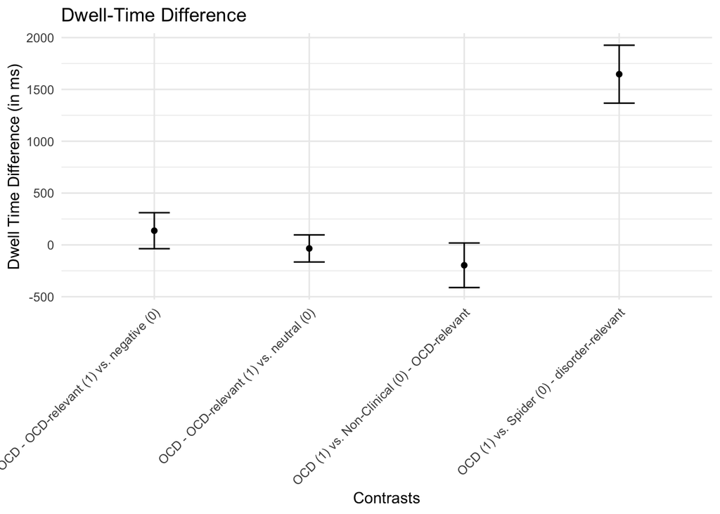

```r
# H1
h1_contrasts$names <- c("OCD - OCD-relevant (1) vs. neutral (0)", "OCD - OCD-relevant (1) vs. negative (0)", "OCD (1) vs. Non-Clinical (0) - OCD-relevant", "OCD (1) vs. Spider (0) - disorder-relevant")

h1_plot <- ggplot(h1_contrasts, aes(x = names, y = Estimate)) +
  geom_point() +
  geom_errorbar(aes(ymin = lower, ymax = upper), width = 0.2) +
  labs(title = "Dwell-Time Difference", y = "Dwell Time Difference (in ms)", x = "Contrasts") +
  theme(axis.text.x = element_text(angle = 45)) +
  theme_minimal() +
  theme(axis.text.x = element_text(angle = 45, hjust = 1)) # Apply 45-degree rotation to x-axis labels

h1_plot
```

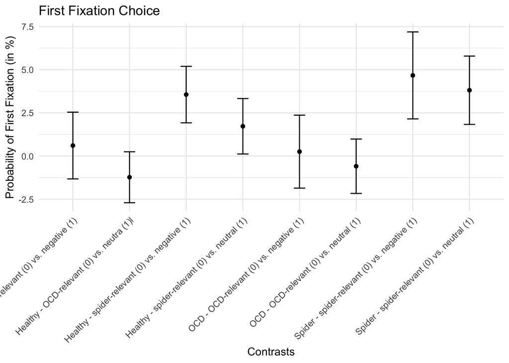

```r
# H2a
h2a_contrasts$names <- c("OCD - OCD-relevant (0) vs. neutral (1)", "OCD - OCD-relevant (0) vs. negative (1)",
                            "Spider - spider-relevant (0) vs. neutral (1)", "Spider - spider-relevant (0) vs. negative (1)",
                            "Healthy - OCD-relevant (0) vs. neutra (1)l", "Healthy - OCD-relevant (0) vs. negative (1)",
                            "Healthy - spider-relevant (0) vs. neutral (1)", "Healthy - spider-relevant (0) vs. negative (1)")

h2a_contrasts <- h2a_contrasts %>%
  dplyr::mutate(Estimate_perc = Estimate*100)
h2a_plot <- ggplot(h2a_contrasts, aes(x = names, y = Estimate_perc)) +
  geom_point() +
  geom_errorbar(aes(ymin = lower*100, ymax = upper*100), width = 0.2) +
  labs(title = "First Fixation Choice", y = "Probability of First Fixation (in %)", x = "Contrasts") +
  theme_minimal() +
  theme(axis.text.x = element_text(angle = 45, hjust = 1))
h2a_plot
```

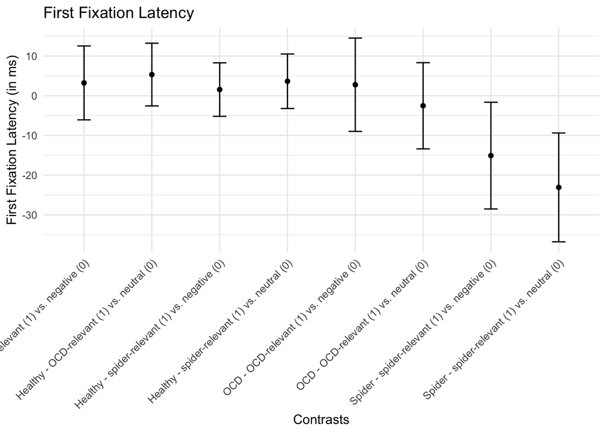

```r
# H2b
h2b_contrasts$names <- c("OCD - OCD-relevant (1) vs. neutral (0)", "OCD - OCD-relevant (1) vs. negative (0)",
                            "Spider - spider-relevant (1) vs. neutral (0)", "Spider - spider-relevant (1) vs. negative (0)",
                            "Healthy - OCD-relevant (1) vs. neutral (0)", "Healthy - OCD-relevant (1) vs. negative (0)",
                            "Healthy - spider-relevant (1) vs. neutral (0)", "Healthy - spider-relevant (1) vs. negative (0)")

h2b_plot <- ggplot(h2b_contrasts, aes(x = names, y = Estimate)) +
  geom_point() +
  geom_errorbar(aes(ymin = lower, ymax = upper), width = 0.2) +
  labs(title = "First Fixation Latency", y = "First Fixation Latency (in ms)", x = "Contrasts") +
  theme_minimal() +
  theme(axis.text.x = element_text(angle = 45, hjust = 1))

h2b_plot
```